# Elaborato per Geospatial Data Analysis (MD2SL 2024) - prof.ssa Bocci

Dario Comanducci

31.01.25

# Il PIL degli Stati africani

## Creazione dataset

```r
rm(list=ls())

library(haven)
# lettura dati
setwd("C:/Users/dario/Documents/Projects/Master/Geospatial/")
stat <- read_dta("data/slave_trade_QJE.dta")

# rinonimo la colonna del PIL Log per capita GDP - from Maddison (2003)
colnames(stat)[colnames(stat) == "ln_maddison_pcgdp2000"] = "ln_pcgdp"
colnames(stat)[colnames(stat) == "ln_coastline_area"] = "ln_coast_area"
colnames(stat)[colnames(stat) == "ln_avg_gold_pop"] = "ln_gold_pop"
colnames(stat)[colnames(stat) == "ln_avg_oil_pop"] = "ln_oil_pop"
colnames(stat)[colnames(stat) == "ln_avg_all_diamonds_pop"] = "ln_diamonds_pop"
colnames(stat)[colnames(stat) == "atlantic_distance_minimum"] = "atlantic_dist_min"
colnames(stat)[colnames(stat) == "indian_distance_minimum"] = "indian_dist_min"
colnames(stat)[colnames(stat) == "saharan_distance_minimum"] = "saharan_dist_min"
colnames(stat)[colnames(stat) == "red_sea_distance_minimum"] = "red_sea_dist_min"


# rimuovo variabili non necessarie
delenda = c(#'abs_latitude', # Absolute latitude
            #'longitude', #Longitude
            'ln_export_pop', #Log total slave exports normalized by historic population
            'island_dum', #Indicator variable for small islands
            #'region_n', # Region indicator: North
            'region_s', # Region indicator: South
            'region_w', # Region indicator: West
            'region_e', # Region indicator: East
            'region_c', # Region indicator: Central
            'ln_pop_dens_1400', # Log population density in 1400
            'ethnic_fractionalization', # Ethnic fractionalization
            'state_dev', # State development
            'land_area') # Land area in millions of square kms
stat[,delenda] = NULL

library(sf)
# lettura shapefile
world = st_read('data/countries/50m/ne_50m_admin_0_countries.shp')
africa = world[which(world$CONTINENT=='Africa'),c('ISO_A3', 'NAME')]

par(mar=c(0,0,0,9))
coords <- st_coordinates(st_centroid(africa))
plot(st_geometry(africa), border='gray', col='snow')
text(coords[, "X"], coords[, "Y"], labels=africa$ISO_A3, cex=0.5)
```

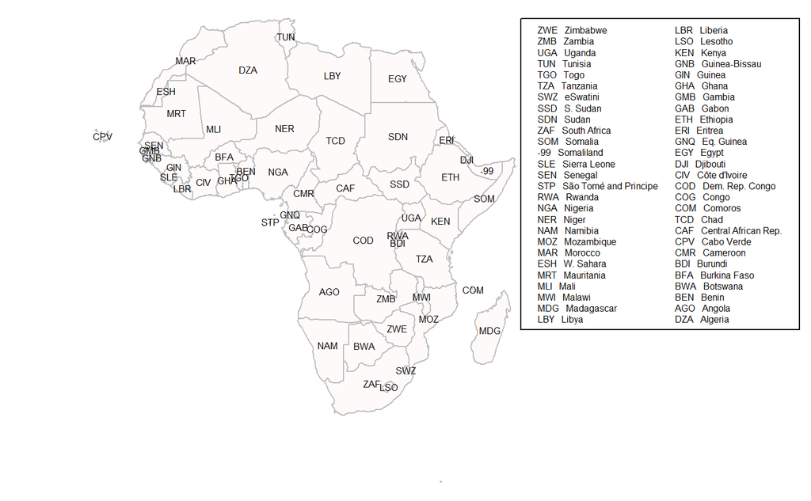

```r
legend(x=st_bbox(africa)$xmax+1, y=st_bbox(africa)$ymax,
       legend = paste(africa$ISO_A3, ' ', africa$NAME), cex=0.5, ncol=2, xpd=T)
par(mar=c(5, 4, 4, 2)+0.1)
```

### Origine del dataset

Esiste un legame causale tra le deportazioni degli schiavi (`ln_export_area`) ed il PIL procapite (`ln_pcgdp`) degli odierni Stati africani?

```r
par(mar=c(4.5,4,0.5,0.5))
plot(x=stat$ln_export_area, y=stat$ln_pcgdp, pch=16, bty='n', cex=0.7,
     xlab='ln_export_area', ylab='ln_pcgdp', col='firebrick')
text(x=stat$ln_export_area, y=stat$ln_pcgdp+0.1, labels=stat$isocode, cex=0.5)
```

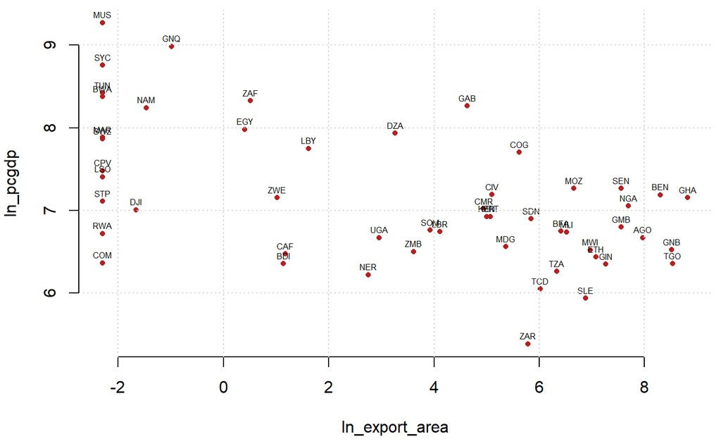

```r
grid()
par(mar=c(5,4,4,2)+0.1)
```

### Rimozione isole

```r
#rimuovo le isole
delenda = c('SYC', # Seychelles
            'STP', # Sao Tome & Principe
            'MUS', # Mauritius
            'MDG', #    Madagascar
            'CPV', #    Cape Verde Islands
            'COM'  #    Comoros
)
stat = stat[!(stat$isocode %in% delenda), ]
africa = africa[!(africa$ISO_A3 %in% delenda),]
```

### Ricostruzione degi vecchi Stati africani

Rispetto a quando i dati sul PIL sono stati raccolti (fine anni ’90), la conformazione politica dell’Africa è cambiata; alcuni Stati si sono separati, per cui è necessario riunificare le loro mappe attuali:

- Sudan e Sudan del Sud riuniti nel Sudan
- Eritrea e Etiopia riuniti in Etiopia
- Somaliland e Somalia riunificati nella Somalia
- Sahara Occidentale e Marocco fusi nel Marocco

```r
merge_countries <- function(sf_data, iso1, iso2, merged_iso, merged_name)
{
   country1 = sf_data[which(sf_data$ISO_A3 == iso1), ]
   country2 = sf_data[which(sf_data$ISO_A3 == iso2), ]
   merged_geometry = st_union(st_geometry(country1), st_geometry(country2))

   merged_data = data.frame(ISO_A3=merged_iso, NAME=merged_name, geometry=merged_geometry)
   merged_sf = st_sf(merged_data, crs=st_crs(sf_data))

   sf_data_filtered = sf_data[!(sf_data$ISO_A3 %in% c(iso1, iso2)), ]
   sf_data_merged = rbind(sf_data_filtered, merged_sf)
   return(sf_data_merged)
}


sameCountries = intersect(africa$ISO_A3, stat$isocode)
tofix_stat = which(!stat$isocode %in% sameCountries)
tofix_shape = which(!africa$ISO_A3 %in% sameCountries)
(stat[tofix_stat, c('country','isocode')])
```

| country | isocode |
| --- | --- |
| Democratic Republic of Congo | ZAR |

```r
(africa[tofix_shape,c('NAME', 'ISO_A3')])
```

```
Simple feature collection with 5 features and 2 fields
Geometry type: MULTIPOLYGON
Dimension:     XY
Bounding box:  xmin: -17.09878 ymin: -13.45381 xmax: 48.93857 ymax: 27.65645
Geodetic CRS:  WGS 84
               NAME ISO_A3                       geometry
52         S. Sudan    SSD MULTIPOLYGON (((33.97607 4....
59       Somaliland    -99 MULTIPOLYGON (((48.93857 11...
105       W. Sahara    ESH MULTIPOLYGON (((-8.817773 2...
174         Eritrea    ERI MULTIPOLYGON (((36.52432 14...
192 Dem. Rep. Congo    COD MULTIPOLYGON (((30.75117 -8...
```

```r
# Rinonimo Dem. Rep. Congo (COD) in Democratic Republic of Congo (ZAR)
africa$ISO_A3[which(africa$ISO_A3=='COD')] = 'ZAR'
africa$NAME[which(africa$ISO_A3=='COD')] = 'Democratic Republic of Congo'

# Eritrea -> Etiopia
africa = merge_countries(africa, 'ERI', 'ETH', 'ETH', 'Ethiope')
sameCountries = intersect(africa$ISO_A3, stat$isocode)
tofix_stat = which(!stat$isocode %in% sameCountries)
tofix_shape = which(!africa$ISO_A3 %in% sameCountries)
(stat[tofix_stat, c('country','isocode')])
```

| country | isocode |
| --- | --- |

```r
(africa[tofix_shape, c('NAME', 'ISO_A3')])
```

```
Simple feature collection with 3 features and 2 fields
Geometry type: MULTIPOLYGON
Dimension:     XY
Bounding box:  xmin: -17.09878 ymin: 3.490723 xmax: 48.93857 ymax: 27.65645
Geodetic CRS:  WGS 84
          NAME ISO_A3                       geometry
52    S. Sudan    SSD MULTIPOLYGON (((33.97607 4....
59  Somaliland    -99 MULTIPOLYGON (((48.93857 11...
105  W. Sahara    ESH MULTIPOLYGON (((-8.817773 2...
```

```r
# W. Sahara -> Morocco
africa = merge_countries(africa, 'ESH', 'MAR', 'MAR', 'Morocco')
sameCountries = intersect(africa$ISO_A3, stat$isocode)
tofix_stat = which(!stat$isocode %in% sameCountries)
tofix_shape = which(!africa$ISO_A3 %in% sameCountries)
(stat[tofix_stat, c('country','isocode')])
```

| country | isocode |
| --- | --- |

```r
(africa[tofix_shape, c('NAME', 'ISO_A3')])
```

```
Simple feature collection with 2 features and 2 fields
Geometry type: MULTIPOLYGON
Dimension:     XY
Bounding box:  xmin: 24.14736 ymin: 3.490723 xmax: 48.93857 ymax: 12.2231
Geodetic CRS:  WGS 84
         NAME ISO_A3                       geometry
52   S. Sudan    SSD MULTIPOLYGON (((33.97607 4....
59 Somaliland    -99 MULTIPOLYGON (((48.93857 11...
```

```r
# Somaliland -> Somalia
africa = merge_countries(africa, '-99', 'SOM', 'SOM', 'Somalia')
sameCountries = intersect(africa$ISO_A3, stat$isocode)
tofix_stat = which(!stat$isocode %in% sameCountries)
tofix_shape = which(!africa$ISO_A3 %in% sameCountries)
(stat[tofix_stat, c('country','isocode')])
```

| country | isocode |
| --- | --- |

```r
(africa[tofix_shape, c('NAME', 'ISO_A3')])
```

```
Simple feature collection with 1 feature and 2 fields
Geometry type: MULTIPOLYGON
Dimension:     XY
Bounding box:  xmin: 24.14736 ymin: 3.490723 xmax: 35.26836 ymax: 12.2231
Geodetic CRS:  WGS 84
       NAME ISO_A3                       geometry
52 S. Sudan    SSD MULTIPOLYGON (((33.97607 4....
```

```r
# S. Sudan -> Sudan
africa = merge_countries(africa, 'SSD', 'SDN', 'SDN', 'Sudan')
sameCountries = intersect(africa$ISO_A3, stat$isocode)
tofix_stat = which(!stat$isocode %in% sameCountries)
tofix_shape = which(!africa$ISO_A3 %in% sameCountries)
(stat[tofix_stat, c('country','isocode')])
```

| country | isocode |
| --- | --- |

```r
(africa[tofix_shape,c('NAME', 'ISO_A3')])
```

```
Simple feature collection with 0 features and 2 fields
Bounding box:  xmin: NA ymin: NA xmax: NA ymax: NA
Geodetic CRS:  WGS 84
[1] NAME     ISO_A3   geometry
<0 rows> (or 0-length row.names)
```

### Rimozione delle isolette di ogni Stato

Rimuoviamo le isole appartenenti ad alcuni Stati (in particolare un arcipelago molto a Sud sotto la nazionalità del Sudafrica)

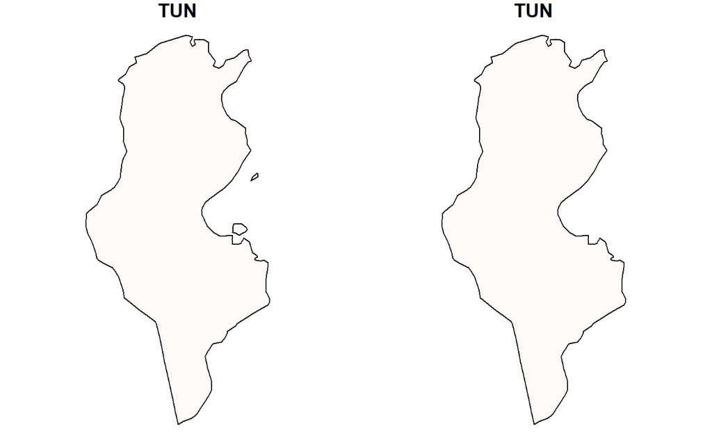

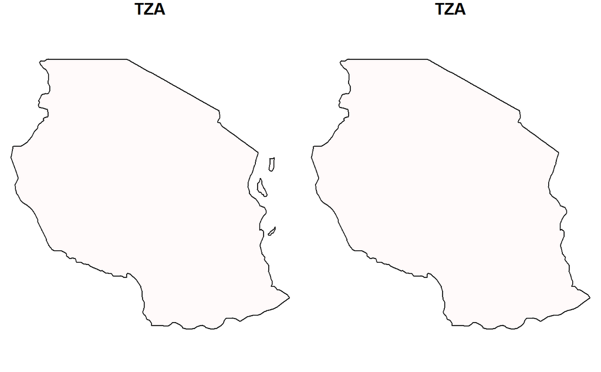

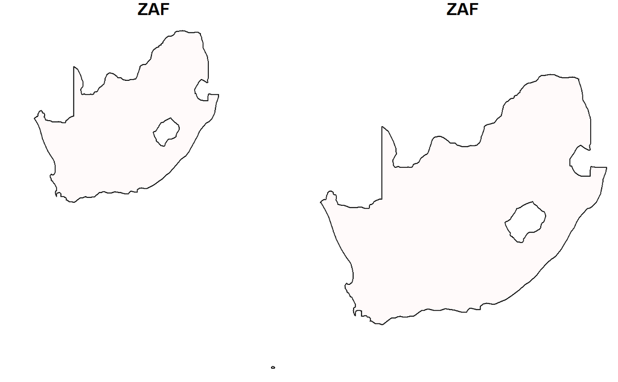

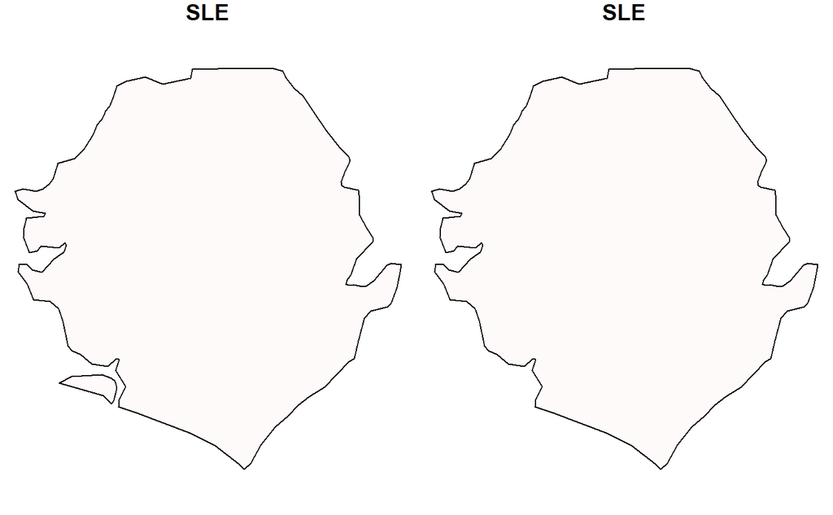

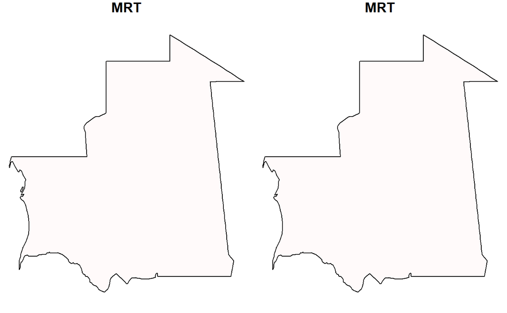

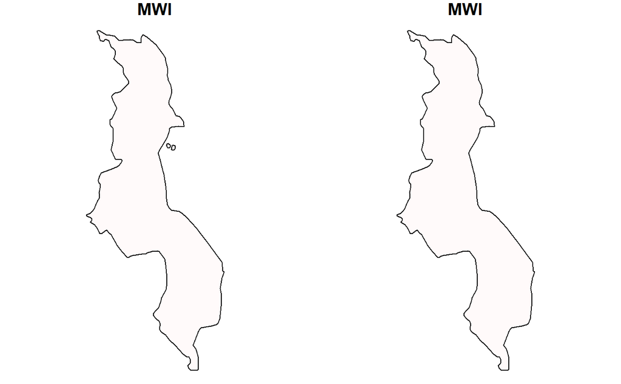

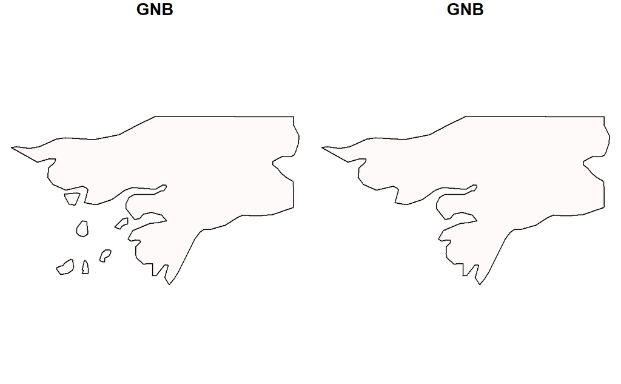

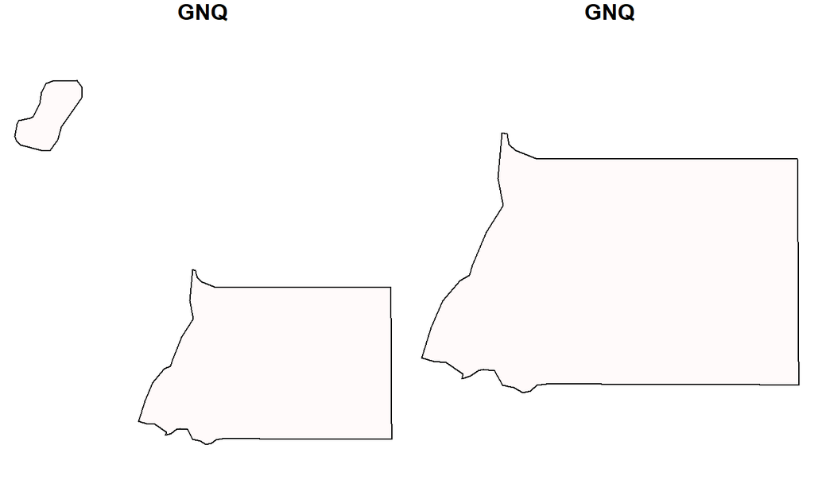

```r
### Rimozione isole
remove_islands <- function(sf, iso_a3)
{
   country = sf[which(sf$ISO_A3 == iso_a3), ]

   if (nrow(country) > 0)
   {

      geom_type <- st_geometry_type(country)[1] # Get the geometry type of the FIRST feature

      if (geom_type %in% c("MULTIPOLYGON"))
      {
         #country_polygons <- st_cast(country, "POLYGON")
         country_polygons <- suppressWarnings(st_cast(country, "POLYGON")) # Suppress warning here

         areas = st_area(country_polygons)
         largest_polygon = country_polygons[which.max(areas),]

         # Extract the geometry of the largest polygon
         country_geom = st_geometry(largest_polygon)[[1]]
         # Create a new sf object for the mainland
         country_mainland_sf = st_sf(data.frame(ISO_A3 = iso_a3, NAME = country$NAME[1]),
                                    geometry = st_sfc(country_geom, crs = st_crs(country)))

         sf_filtered = sf[!(sf$ISO_A3 %in% iso_a3), ]
         sf_final <- rbind(sf_filtered, country_mainland_sf)

         return(sf_final)
      }
   }

   return(sf)
}


# Rimozione delle isole di ogni stato
delenda = c('TUN', # Tunisia
            'TZA', # Tanzania
            'ZAF', # S. Africa
            'SLE', # Sierra Leone
            'MRT', # Mauritania
            'MWI', # Malawi
            'GNB', # Guinea-Bissau
            'GNQ', # Eq. Guinea
            'ETH') # Ethiope

par(mfrow = c(1, 2), mar=c(0,0,1,0))
for (c in delenda)
{
   plot(st_geometry(africa[which(africa$ISO_A3==c),'ISO_A3']), main=c, col='snow')
   africa = remove_islands(africa, c)
   plot(st_geometry(africa[which(africa$ISO_A3==c),'ISO_A3']), main=c, col='snow')
}
```

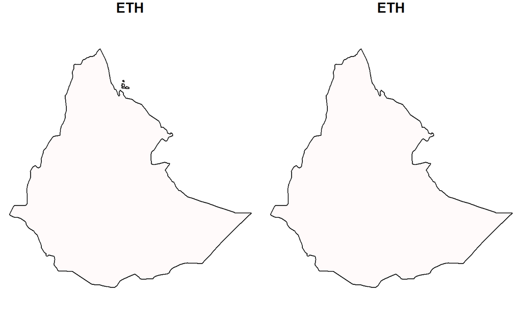

```r
par(mfrow = c(1,1), mar=c(5, 4, 4, 2)+0.1)
```

### Merge dei dataset

```r
names(africa)[1:2] = names(stat[1:2])
stat$country = NULL #non mi serve più
ds = merge(africa, stat, by = "isocode")

coords <- st_coordinates(st_centroid(ds))
par(mar=c(0,0,0,8))
plot(st_geometry(ds), border='gray', col='snow')
text(coords[, "X"], coords[, "Y"], labels=ds$isocode, cex=0.5)
```

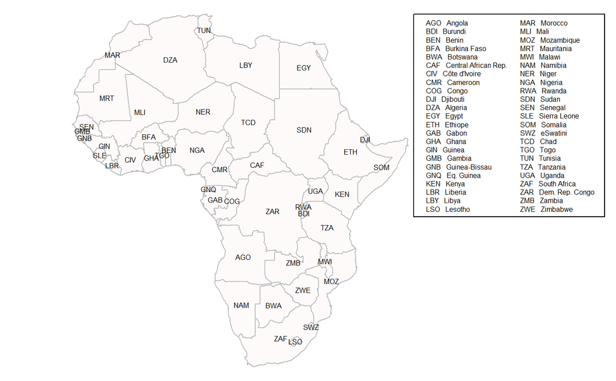

```r
legend(x=st_bbox(ds)$xmax+1, y=st_bbox(ds)$ymax,
       legend = paste(ds$isocode, ' ', ds$country), cex=0.5, ncol=2, xpd=T)
par(mar=c(5, 4, 4, 2)+0.1)
```

### Proiezione cartografica e conversione in SpatialPolygonsDataFrame

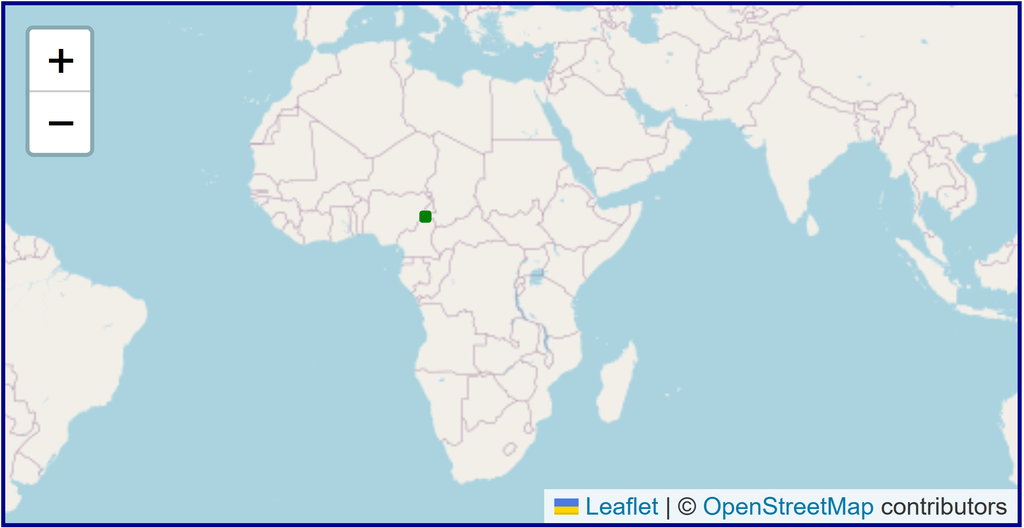

*EPSG:2312* Garoua / UTM zone 33N (https://spatialreference.org/ref/epsg/2312/)

```r
#utm <- st_crs("+proj=utm +zone=33 +north +datum=WGS84 +units=m +no_defs")
utm <- st_crs(2312)
sf_utm <- st_transform(ds, crs = utm)
st_crs(sf_utm)
```

```
Coordinate Reference System:
  User input: EPSG:2312
  wkt:
PROJCRS["Garoua / UTM zone 33N",
    BASEGEOGCRS["Garoua",
        DATUM["Garoua",
            ELLIPSOID["Clarke 1880 (RGS)",6378249.145,293.465,
                LENGTHUNIT["metre",1]]],
        PRIMEM["Greenwich",0,
            ANGLEUNIT["degree",0.0174532925199433]],
        ID["EPSG",4197]],
    CONVERSION["UTM zone 33N",
        METHOD["Transverse Mercator",
            ID["EPSG",9807]],
        PARAMETER["Latitude of natural origin",0,
            ANGLEUNIT["degree",0.0174532925199433],
            ID["EPSG",8801]],
        PARAMETER["Longitude of natural origin",15,
            ANGLEUNIT["degree",0.0174532925199433],
            ID["EPSG",8802]],
        PARAMETER["Scale factor at natural origin",0.9996,
            SCALEUNIT["unity",1],
            ID["EPSG",8805]],
        PARAMETER["False easting",500000,
            LENGTHUNIT["metre",1],
            ID["EPSG",8806]],
        PARAMETER["False northing",0,
            LENGTHUNIT["metre",1],
            ID["EPSG",8807]]],
    CS[Cartesian,2],
        AXIS["(E)",east,
            ORDER[1],
            LENGTHUNIT["metre",1]],
        AXIS["(N)",north,
            ORDER[2],
            LENGTHUNIT["metre",1]],
    USAGE[
        SCOPE["Engineering survey, topographic mapping."],
        AREA["Cameroon - Garoua area."],
        BBOX[8.92,12.9,9.87,14.19]],
    ID["EPSG",2312]]
```

```r
par(mfrow = c(1, 2), mar=c(0,0,2,0))
plot(st_geometry(ds), col = "lightcyan", main = "Original Projection")
plot(st_geometry(sf_utm), col = "lightyellow", main = "EPSG:2312 Projection")
```

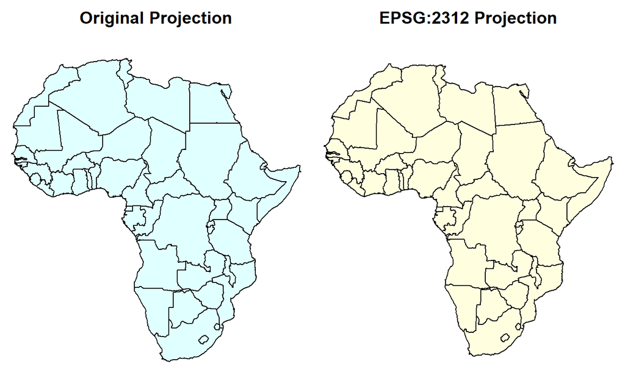

```r
par(mfrow = c(1, 1), mar=c(5, 4, 4, 2)+0.1)
```

```r
# Lo salvo come shapefile per aprirlo in Geoda
# Save as Shapefile
st_write(sf_utm, "./data/slaveTrade.shp", driver="ESRI Shapefile", delete_layer=T)
```

```
Deleting layer `slaveTrade' using driver `ESRI Shapefile'
Writing layer `slaveTrade' to data source
  `./data/slaveTrade.shp' using driver `ESRI Shapefile'
Writing 46 features with 29 fields and geometry type Unknown (any).
```

```r
# Lo converto in SpatialPolygonDataFrame per ri-usare codice prof
slaveTrade = as_Spatial(sf_utm)
```

# Descrizione del dataset

- `isocode` Country isocode
- `country` Country name
- `ln_pcgdp` Log per capita GDP - from Maddison (2003)
- `ln_export_area` Log total slave exports normalized by land area
- `colony0` Colonizer indicator: not colonized
- `colony1` Colonizer indicator: Britan
- `colony2` Colonizer indicator: France
- `colony3` Colonizer indicator: Portugal
- `colony4` Colonizer indicator: Belgium
- `colony5` Colonizer indicator: Spain
- `colony6` Colonizer indicator: UN
- `colony7` Colonizer indicator: Italy
- `abs_latitude` Absolute latitude
- `longitude` Longitude
- `rain_min` Min of monthly average rainfall (mm)
- `humid_max` Max of monthly afternoon avg humidity (%)
- `low_temp` Min of avg monthly low temp (C)
- `ln_coastline_area` Log (coastline/land_area)
- `islam` Percent Islamic
- `legor_fr` Legal origin indicator: French
- `legor_uk` Legal origin indicator: British
- `region_n` Region indicator: North Africa
- `ln_avg_gold_pop` Log gold production per capita
- `ln_avg_oil_pop` Log oil production per capita
- `ln_avg_all_diamonds_pop` Log diamond production per capita
- `atlantic_distance_minimum` Minimum Atlantic distance (000s of kms)
- `indian_distance_minimum` Minimum Indian distance (000s of kms)
- `saharan_distance_minimum` Minimum Saharan distance (000s of kms)
- `red_sea_distance_minimum` Minimum Red Sea distance (000s of kms)

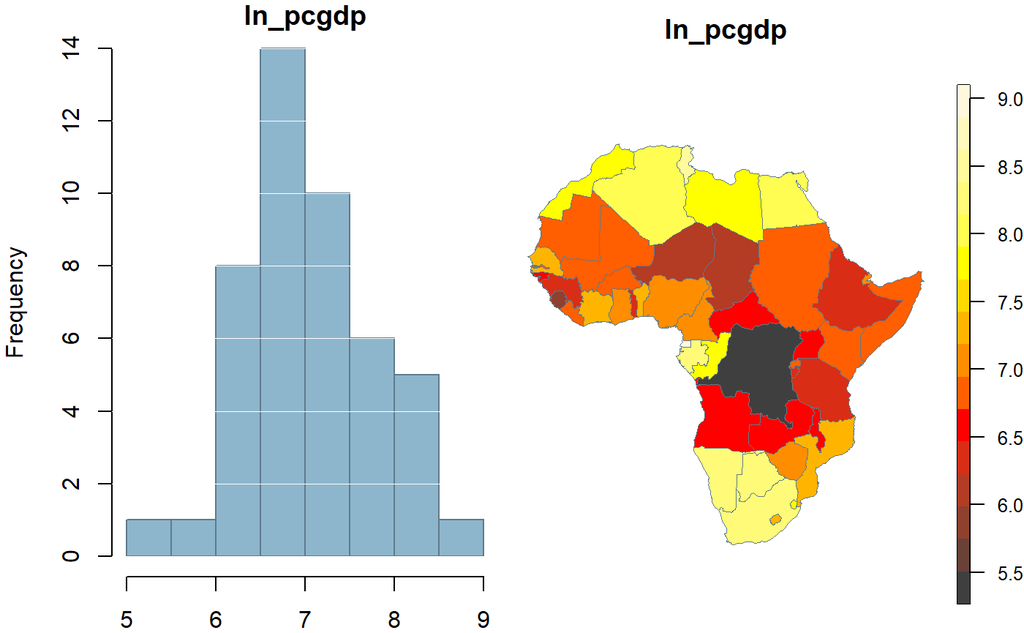

```r
library(sp)
library(spdep)
library(spatialreg)
library(RColorBrewer)
library(fields) # For the colorbar
library(gridExtra)
matlab.like.hot <- function(n)
{

   #my_gradient = c('gray25', 'red', 'yellow', 'floralwhite')
   my_gradient = c('gray25', 'red', 'yellow', 'cornsilk')
   #my_gradient = c('gray25', 'red', 'yellow', 'lightgoldenrodyellow')
   #my_gradient = c('gray25', 'red', 'yellow', 'lightyellow')
   #my_gradient = c('gray25', 'red', 'yellow', 'lemonchiffon')
   #my_gradient = c('gray25', 'red', 'yellow', 'snow')
   #my_gradient = c('gray25', 'red', 'yellow', 'ivory')
   return (colorRampPalette(my_gradient, space = "Lab")(n))
}

plotMapData <- function(shp, vname, min_v=NA, max_v=NA)
{
   n_colors <- 16
   # spectral_colors = brewer.pal(11, "Spectral")
   # spectral_r_palette <- colorRampPalette(rev(spectral_colors)) # Reverse for _r
   palette = matlab.like.hot(n_colors) #spectral_r_palette(n_colors)

   idv = which(names(shp)==vname)
   vals = shp[[idv]]

   if (is.na(min_v)) (min_v = min(vals))
   if (is.na(max_v)) (max_v = max(vals))
   if (min_v == max_v)
   {
      (min_v = floor(min(vals)))
      (max_v = ceiling(max(vals)))
   }

   norm_v = ((vals - min_v) / (max_v - min_v))
   norm_v[norm_v < 0] = 0
   norm_v[norm_v > 1] = 1
   pcol = palette[round(norm_v * (n_colors-1)) + 1]

   par(mar = c(0.0, 0.0, 2.0, 3))
   plot(shp, col = pcol,  lwd=0.5, main=vname, border='lightskyblue4')
   # Colorbar
   image.plot(legend.only = TRUE, zlim = c(min_v, max_v),
           col = palette,
           axis.args=list(cex.axis=0.8))
   par(mar=c(5,4,4,2) + 0.1)# Reset to default layout

   # spplot(shp, vname, main=vname, lwd=0.5,
   #        col = 'lightskyblue4',
   #     col.regions = palette,
   #     par.settings = list(axis.line = list(col = NA)))


}

showData <- function(shp, col_name, min_v=NA, max_v=NA)
{
   #par(mfrow = c(1, 2), mar = c(3, 4, 1.0, 0.5))
   par(mfrow = c(1, 2), mar = c(2, 4, 1.0, 0.5))

   h = hist(shp[[col_name]],main=col_name,xlab='',
        col='lightskyblue3', border='lightskyblue4')#, breaks='FD',)
   grid(lty='solid', lwd=0.5, col='white', nx=NA, ny=NULL)

   plotMapData(shp, col_name)

   par(mfrow=c(1,1), mar=c(5,4,4,2)+0.1)
}

#--------------------------------------------------------------------



#ln_maddison_pcgdp2000
showData(slaveTrade,'ln_pcgdp')
```

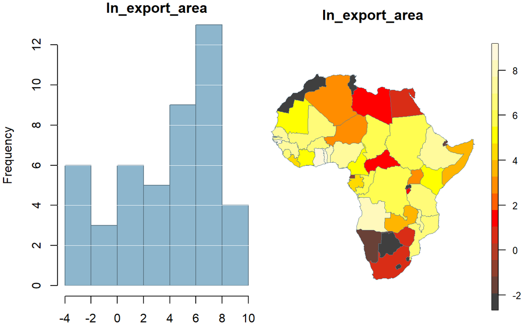

```r
#ln_export_area
showData(slaveTrade,'ln_export_area')
```

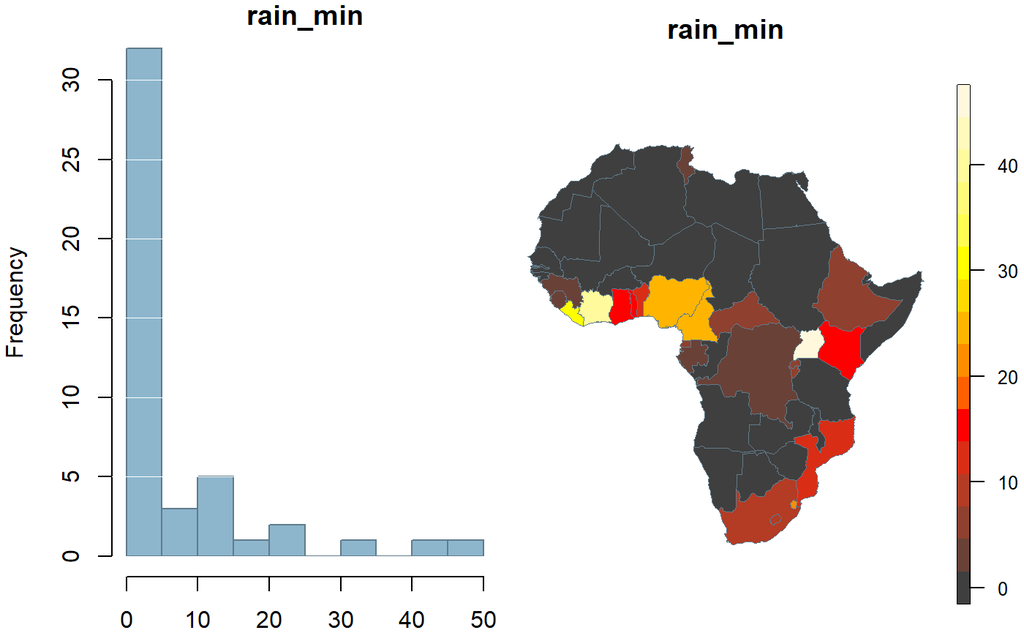

```r
# rain_min
showData(slaveTrade,'rain_min')
```

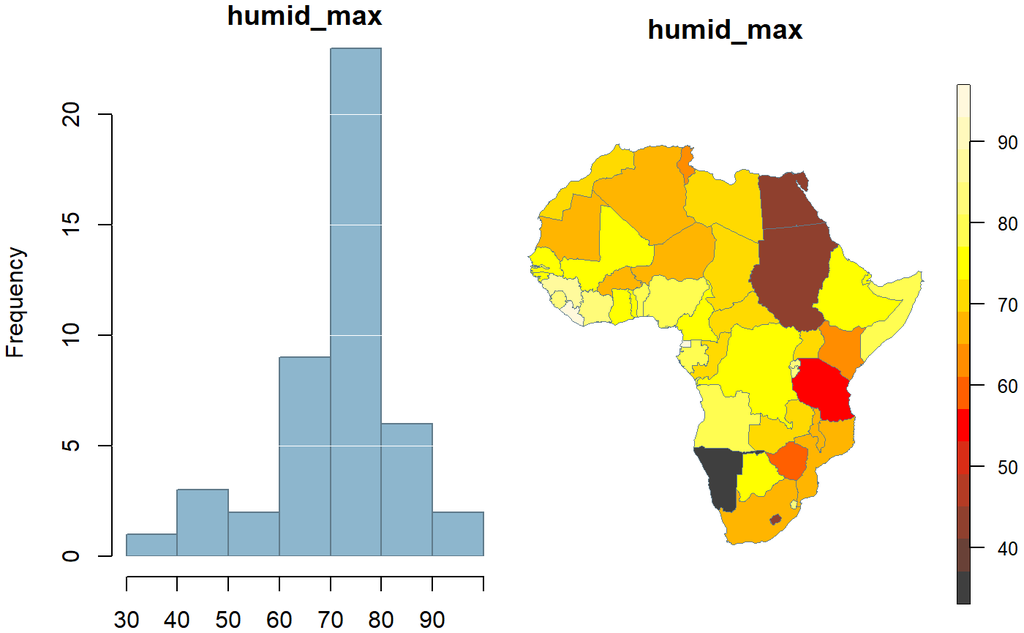

```r
# humid_max
showData(slaveTrade,'humid_max')
```

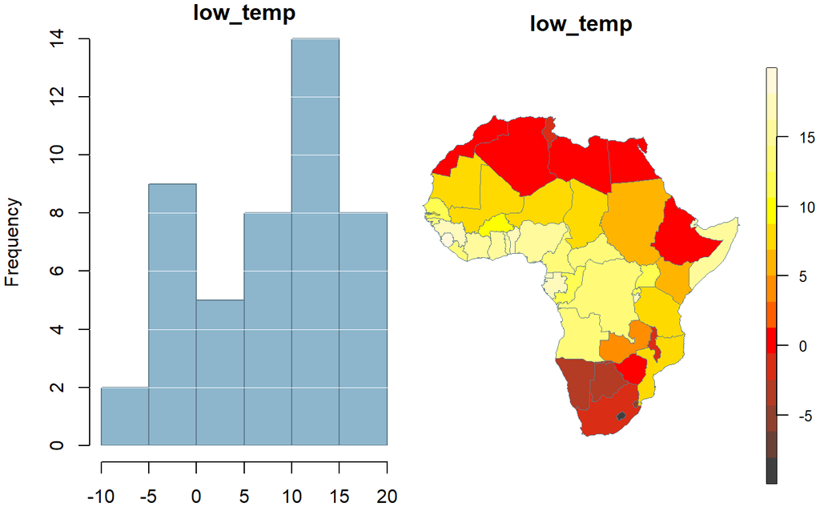

```r
# low_temp
showData(slaveTrade,'low_temp')
```

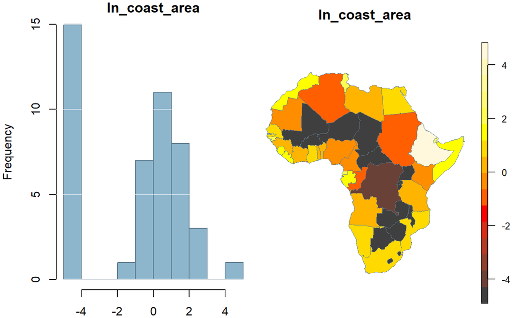

```r
# ln_coastline_area
showData(slaveTrade,'ln_coast_area')
```

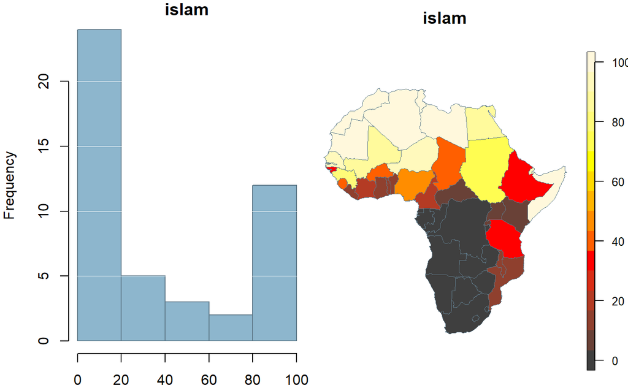

```r
# islam
showData(slaveTrade,'islam')
```

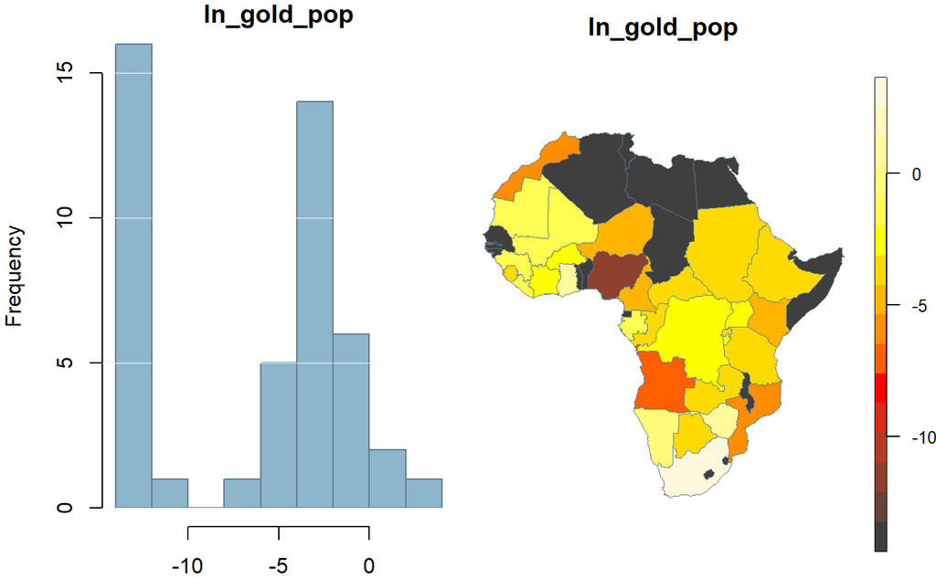

```r
# ln_avg_gold_pop
showData(slaveTrade,'ln_gold_pop')
```

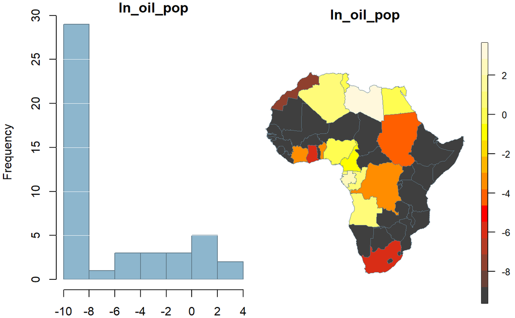

```r
# ln_avg_oil_pop
showData(slaveTrade,'ln_oil_pop')
```

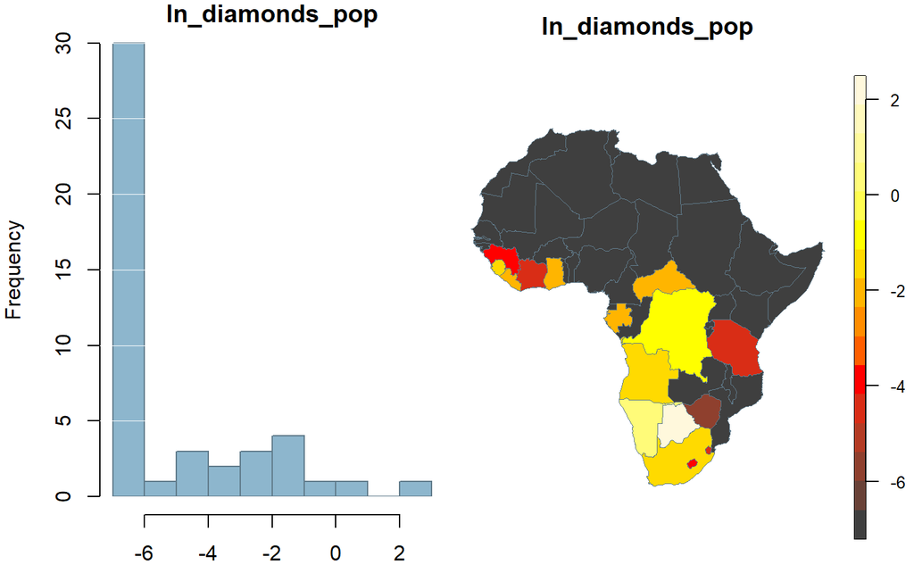

```r
# ln_avg_all_diamonds_pop
showData(slaveTrade,'ln_diamonds_pop')
```

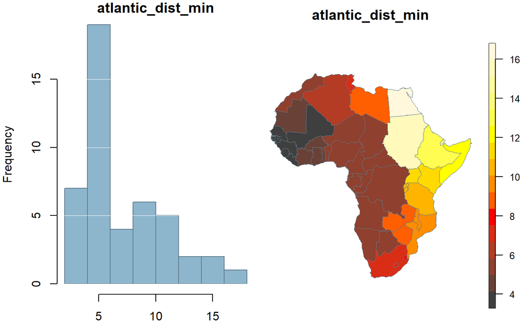

```r
# atlantic_distance_minimum
showData(slaveTrade,'atlantic_dist_min')
```

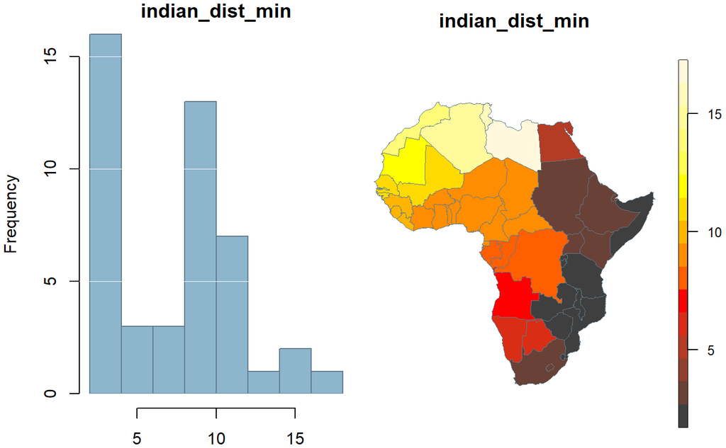

```r
# indian_distance_minimum
showData(slaveTrade,'indian_dist_min')
```

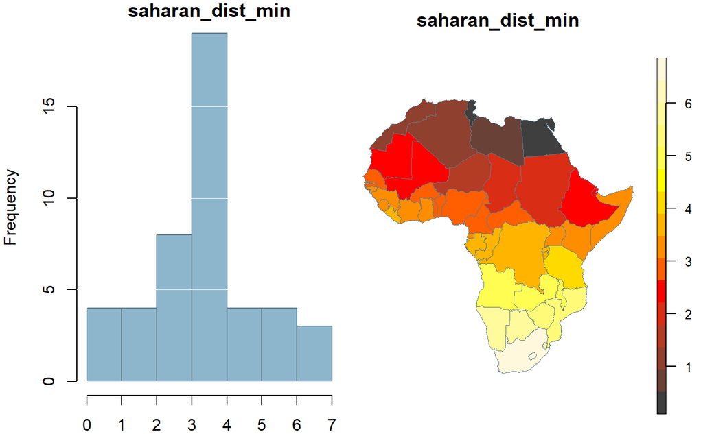

```r
# saharan_distance_minimum
showData(slaveTrade,'saharan_dist_min')
```

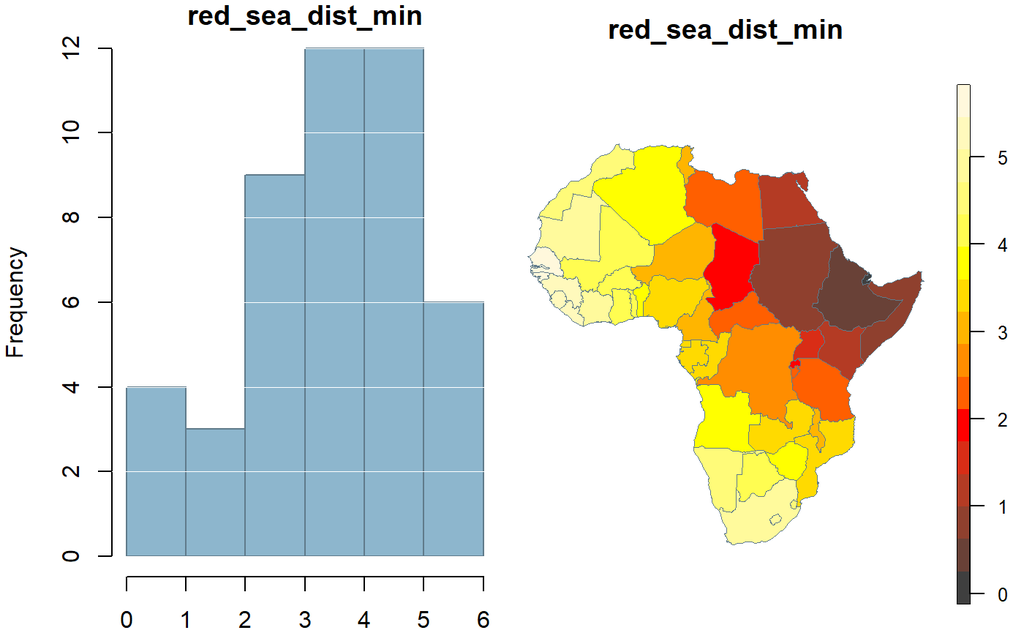

```r
# red_sea_distance_minimum
showData(slaveTrade,'red_sea_dist_min')
```

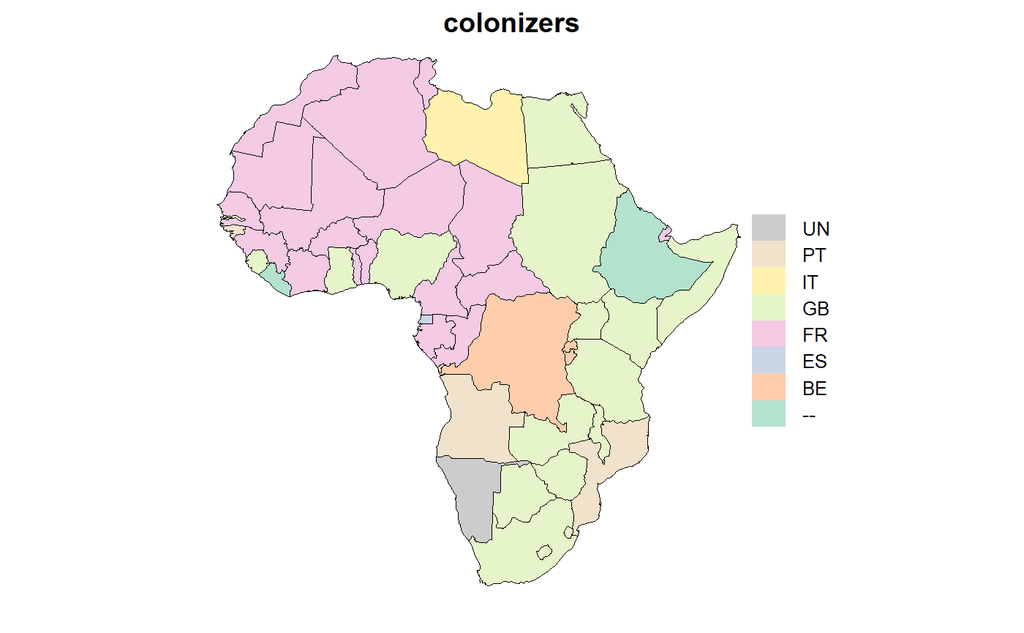

```r
#..........................................................
colony_codes = c('--', 'GB', 'FR', 'PT', 'BE', 'ES', 'UN', 'IT')
#colony_names = names(slaveTrade)[5:12]
colony_names = c('colony0', 'colony1', 'colony2', 'colony3', 'colony4', 'colony5', 'colony6', 'colony7')
colony_id = max.col(stat[,colony_names])
slaveTrade$colony = as.factor(colony_codes[colony_id])

legor_codes = c('FR', 'GB', '--')
legor_names = c('legor_fr', 'legor_uk')
legor_id = max.col(stat[,legor_names])
slaveTrade$legor = legor_codes[legor_id]
slaveTrade$legor[rowSums(stat[,legor_names]) == 0] = '--'
slaveTrade$legor = as.factor(legor_codes[legor_id])

library(gridExtra)
#pL =
spplot(slaveTrade, 'colony', main='colonizers',  lwd=0.5,
            col.regions = brewer.pal(n=length(colony_codes), name='Pastel2'), par.settings = list(axis.line = list(col = NA)))
```

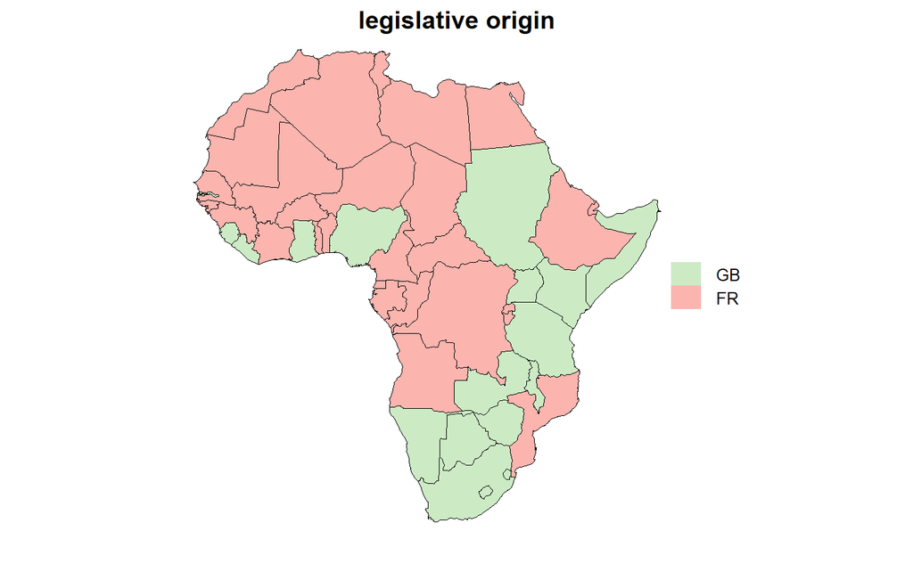

```r
# pR =
spplot(slaveTrade, 'legor', main='legislative origin', lwd=0.5,
            col.regions = brewer.pal(n=length(legor_codes), name='Pastel1'), par.settings = list(axis.line = list(col = NA)))
```

```r
#grid.arrange(pL, pR, ncol = 2)
```

## Analisi di correlazione (variabili continue)

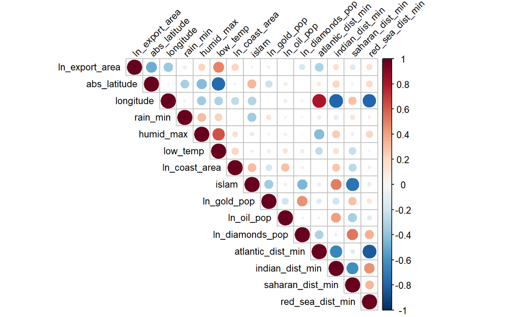

```r
library(corrplot)
#(preds = names(slaveTrade)[c(3:4,13:18, 20:26)])
preds = c('ln_export_area', 'abs_latitude', 'longitude',
          'rain_min', 'humid_max', 'low_temp', 'ln_coast_area',
          'islam', 'ln_gold_pop', 'ln_oil_pop', 'ln_diamonds_pop',
          'atlantic_dist_min', 'indian_dist_min',
          'saharan_dist_min', 'red_sea_dist_min')
corpredictor = cor(slaveTrade@data[,preds], method="pearson")

par(mar=c(0,0,0,0))
corrplot(corpredictor, type = "upper", col=rev(colorRampPalette(brewer.pal(n=11, name='RdBu'))(100)), tl.col = "black", tl.srt = 45, tl.cex=0.8)
par(mar=c(5,4,4,2)+0.1)
```

```r
(corpredictor['abs_latitude', 'low_temp'])
```

```
[1] -0.7768648
```

```r
(corpredictor['longitude', c('atlantic_dist_min', 'indian_dist_min', 'red_sea_dist_min')])
```

```
atlantic_dist_min   indian_dist_min  red_sea_dist_min
        0.8145862        -0.7918568        -0.7828318
```

```r
(corpredictor['islam', 'saharan_dist_min'])
```

```
[1] -0.7350223
```

```r
(corpredictor['atlantic_dist_min', 'red_sea_dist_min'])
```

```
[1] -0.8306802
```

# Ispezione geospaziale dei dati

## Determinazione dei vicini

```r
slaveTrade.nb <- poly2nb(slaveTrade)
slaveTrade.lw <- nb2listw(slaveTrade.nb, style = "W")
slaveTrade.nb.lag = nblag(slaveTrade.nb, maxlag=5)


summary(slaveTrade.nb)
```

```
Neighbour list object:
Number of regions: 46
Number of nonzero links: 202
Percentage nonzero weights: 9.546314
Average number of links: 4.391304
Link number distribution:

1 2 3 4 5 6 7 8 9
2 8 7 7 8 8 2 3 1
2 least connected regions:
17 23 with 1 link
1 most connected region:
44 with 9 links
```

```r
summary(slaveTrade.lw)
```

```
Characteristics of weights list object:
Neighbour list object:
Number of regions: 46
Number of nonzero links: 202
Percentage nonzero weights: 9.546314
Average number of links: 4.391304
Link number distribution:

1 2 3 4 5 6 7 8 9
2 8 7 7 8 8 2 3 1
2 least connected regions:
17 23 with 1 link
1 most connected region:
44 with 9 links

Weights style: W
Weights constants summary:
```

|  | n | nn | S0 | S1 | S2 |
| --- | --- | --- | --- | --- | --- |
| W | 46 | 2116 | 46 | 24.11432 | 197.1064 |

```r
cnb = coordinates(slaveTrade)
par(mfrow=c(1,1), mar=c(0,0,1,0))
plot(slaveTrade, border='gray', lwd=0.5, main='prox. lag 1')
plot(slaveTrade.nb.lag[[1]], cnb, add=T, col='red', pch=16, cex=0.5, lwd=0.5)
```

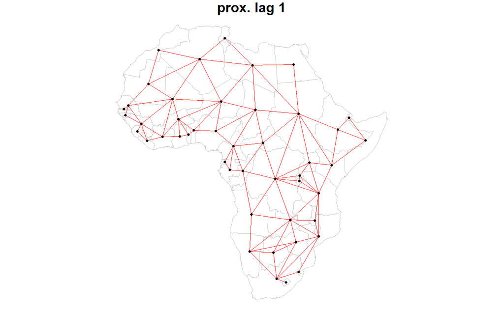

```r
#
par(mfrow=c(2,2), mar=c(0,0,1,0))
```

```r
#
plot(slaveTrade, border='gray', main='prox. lag 2', lwd=0.5)
plot(slaveTrade.nb.lag[[2]], cnb, add=T, col='red', pch=16, cex=0.3, lwd=0.5)
```

```r
#
plot(slaveTrade, border='gray', main='prox. lag 3', lwd=0.5)
plot(slaveTrade.nb.lag[[3]], cnb, add=T, col='red', pch=16, cex=0.3, lwd=0.5)
```

```r
#
plot(slaveTrade, border='gray', main='prox. lag 4', lwd=0.5)
plot(slaveTrade.nb.lag[[4]], cnb, add=T, col='red', pch=16, cex=0.3, lwd=0.5)
```

```r
#
plot(slaveTrade, border='gray', main='prox. lag 5', lwd=0.5)
plot(slaveTrade.nb.lag[[5]], cnb, add=T, col='red', pch=16, cex=0.3, lwd=0.5)
```

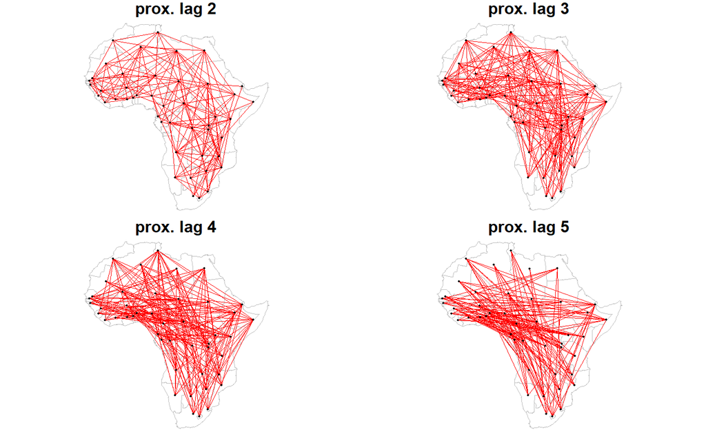

```r
par(mfrow=c(2,2), mar=c(5, 4, 4, 2)+0.1)
```

## Tabella complessiva dei global Moran per tutte le variabili

```
[1] "ln_pcgdp"
```

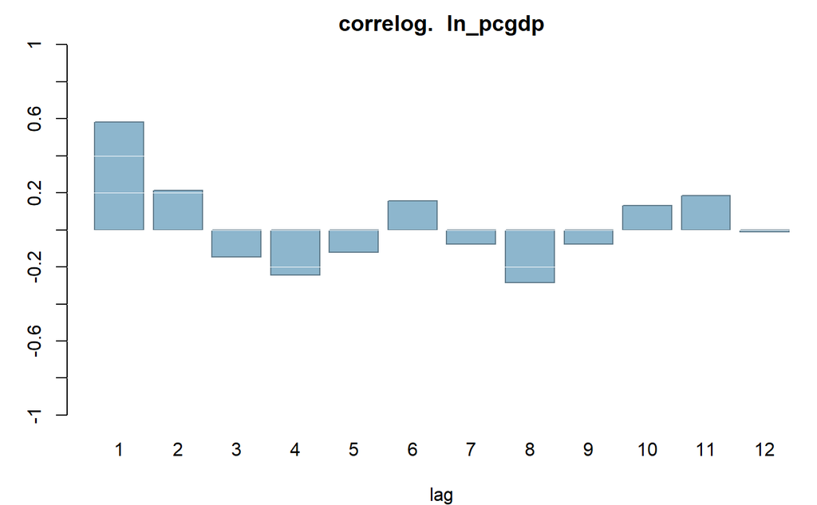

```
[1] "ln_export_area"
```

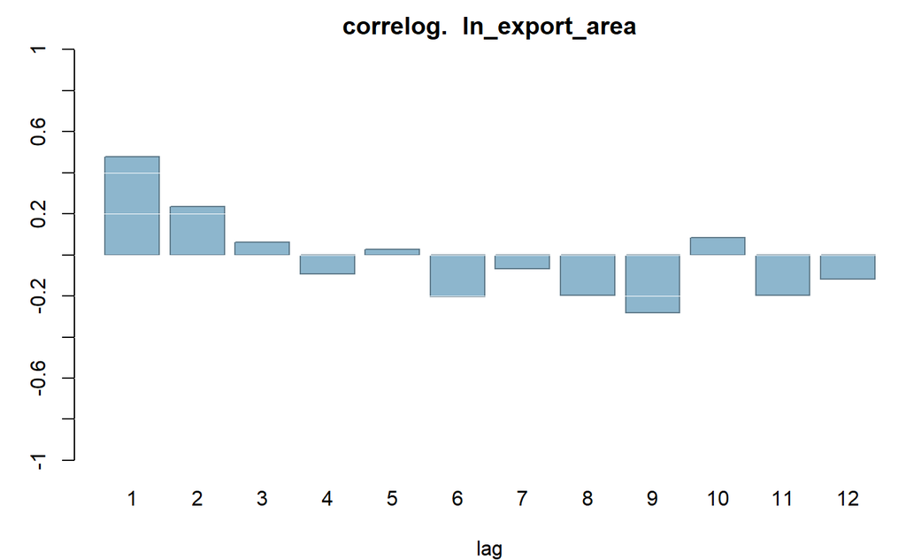

```
[1] "rain_min"
```

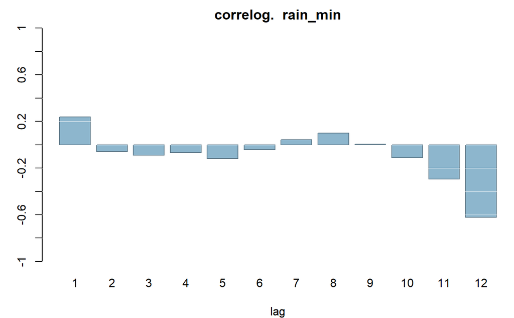

```
[1] "humid_max"
```

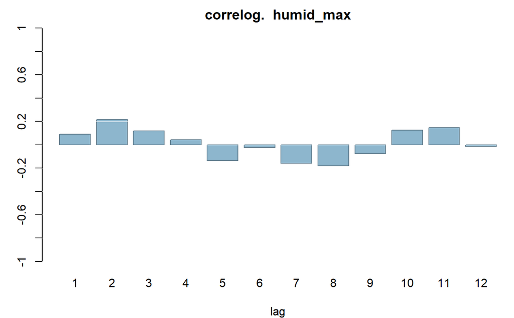

```
[1] "low_temp"
```

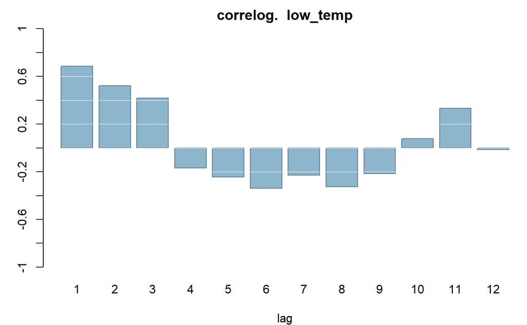

```
[1] "ln_coast_area"
```

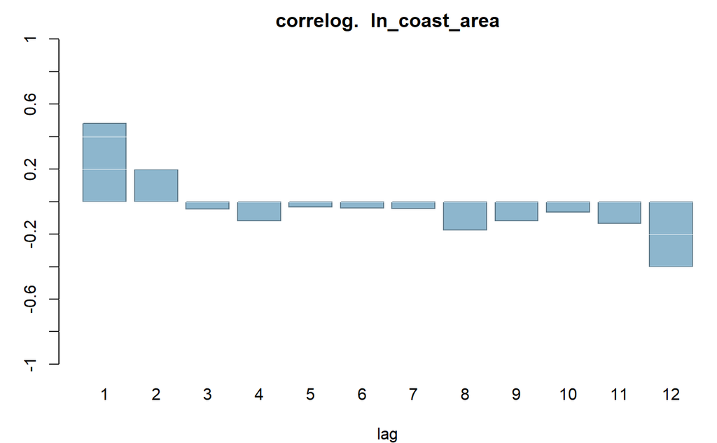

```
[1] "islam"
```

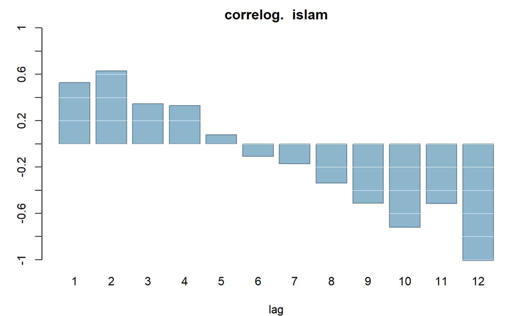

```
[1] "ln_gold_pop"
```

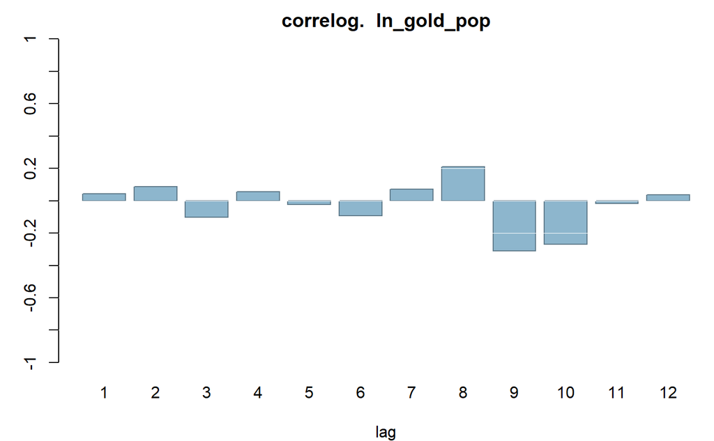

```
[1] "ln_oil_pop"
```

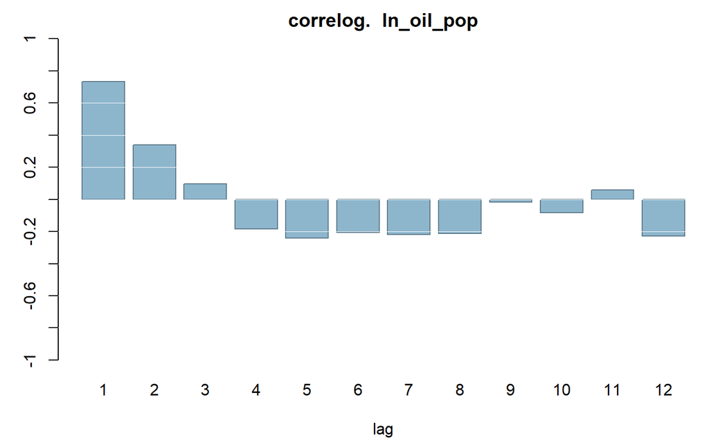

```
[1] "ln_diamonds_pop"
```

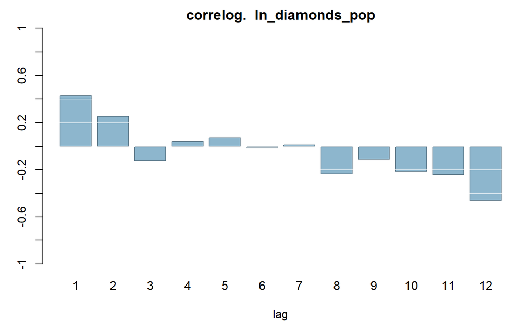

```
[1] "atlantic_dist_min"
```

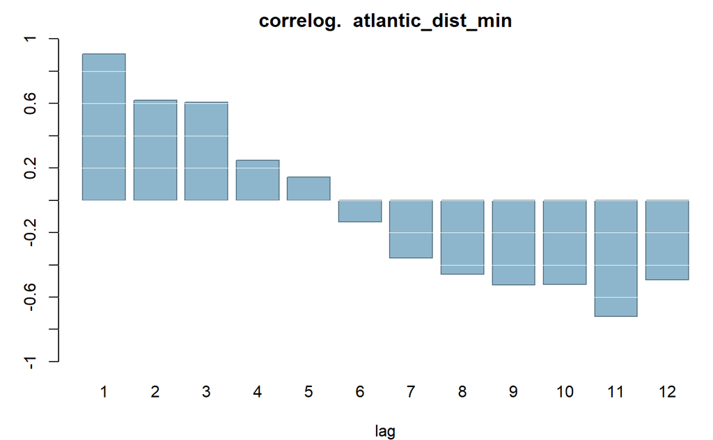

```
[1] "indian_dist_min"
```

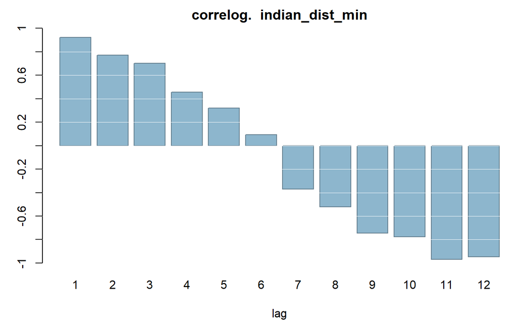

```
[1] "saharan_dist_min"
```

[2 more figures not shown]

```r
library(pgirmess)

moran_list = list()
#cvars = names(slaveTrade)[c(3,4,13:26)]
cvars = c("ln_pcgdp", "ln_export_area", "rain_min", "humid_max", "low_temp", "ln_coast_area",
"islam",
"ln_gold_pop","ln_oil_pop", "ln_diamonds_pop",
"atlantic_dist_min", "indian_dist_min", "saharan_dist_min", "red_sea_dist_min")

for (varname in cvars)
{
   vals = slaveTrade[[varname]]
   resM = moran.test(vals, slaveTrade.lw)
   resG = geary.test(vals, slaveTrade.lw)
   moran_list = rbind(moran_list, c(varname, resM$estimate[1], resM$p.value, resG$estimate[1], resG$p.value))

corD<-correlog(coordinates(slaveTrade), slaveTrade[[varname]], method="Moran")

par(mar=c(4, 3, 2, 0))
barplot(corD[,'coef'], names.arg=1:length(corD[,'coef']), yaxt = "n",
        main=paste('correlog. ', varname), xlab='lag', ylim=c(-1,1),
        col='lightskyblue3', border='lightskyblue4')
axis(2,  # 2 indicates the left axis (y-axis)
     at = seq(-1,1,0.2),  # Positions of the ticks
     labels = seq(-1,1,0.2))
#grid(lty='solid', lwd=0.5, col='white', nx=NA, ny=NULL)
abline(h = seq(-1,1,0.2), col = "white", lty = 'solid', lwd=0.5) # Add gridlines at y_ticks
par(mar=c(5, 4, 4, 2)+0.1)
print(varname)

}
```

```r
print(moran_list)
```

```
                          Moran I statistic
 [1,] "ln_pcgdp"          "0.423212218627437" "5.84693606250667e-06"
 [2,] "ln_export_area"    "0.305517058870406" "0.000707523106463913"
 [3,] "rain_min"          "0.164251212033616" "0.0270892478720973"
 [4,] "humid_max"         "0.273673184682141" "0.00146370187499353"
 [5,] "low_temp"          "0.569670215279815" "3.870356674188e-09"
 [6,] "ln_coast_area"     "0.242017671557775" "0.00510666852032284"
 [7,] "islam"             "0.705157163497059" "7.96725428967743e-13"
 [8,] "ln_gold_pop"       "0.174254358907525" "0.0284356869275728"
 [9,] "ln_oil_pop"        "0.467275141106285" "7.95651993408283e-07"
[10,] "ln_diamonds_pop"   "0.313794535588015" "0.000427916545590119"
[11,] "atlantic_dist_min" "0.725556284996984" "6.49073307389046e-14"
[12,] "indian_dist_min"   "0.803117454548449" "3.44740790902477e-16"
[13,] "saharan_dist_min"  "0.87224731941177"  "6.07174170092653e-19"
[14,] "red_sea_dist_min"  "0.871485990898349" "1.06323009420501e-18"
      Geary C statistic
 [1,] "0.562737299594007"  "5.5455869476088e-05"
 [2,] "0.551065826441476"  "1.47133692708474e-05"
 [3,] "0.799389686320364"  "0.0686756946949285"
 [4,] "0.647335019269922"  "0.00217855925159111"
 [5,] "0.326450740075291"  "2.62229760519281e-10"
 [6,] "0.683154733931286"  "0.00145453722187371"
 [7,] "0.286658983545689"  "8.78501766139294e-12"
 [8,] "0.801654331091"     "0.0291452887728903"
 [9,] "0.522042351663106"  "8.61703934180597e-06"
[10,] "0.674172952769783"  "0.00274798696239173"
[11,] "0.242008049696664"  "3.78528596268506e-11"
[12,] "0.205462740496694"  "2.38830906084901e-13"
[13,] "0.0968316131722766" "1.04236233334834e-15"
[14,] "0.105249867609864"  "2.72806775219181e-16"
```

```r
showMoran <- function(shf, lmii, tlab, roi)
{
   n_colors = 256
   my_gradient = c('deepskyblue3', 'snow', 'firebrick3')
   palette = colorRampPalette(my_gradient, space = "Lab")(n_colors)


   vals = lmii[,1]
   #min_v = min(vals); max_v = max(vals);
   ref_v = 1;#max(abs(vals))
   min_v = -ref_v; max_v = ref_v;
   norm_v = (vals-min_v)/(max_v-min_v)
   norm_v[norm_v < 0] = 0
   norm_v[norm_v > 1] = 1
   pcol = palette[round(norm_v * (n_colors-1)) + 1]

   #tcol = ifelse(lmii[,5]>0.05, "darkgrey", "black")
   tcol = ifelse(1:length(vals) %in% roi, 'black', 'darkgray')
   lcex = ifelse(1:length(vals) %in% roi, 0.7, 0.5)

   par(mar = c(0.0, 0.0, 1.0, 3))

   plot(shf, col=pcol, lwd=0.5, border='olivedrab', main=paste('local Moran: ', tlab))

   # Colorbar
   image.plot(legend.only = TRUE, zlim = c(min_v, max_v),
           col = palette,
           axis.args=list(cex.axis=0.8))

   coords = coordinates(slaveTrade)
   text(coords[,1], coords[,2], labels=ds$isocode, cex=lcex, col=tcol)

   par(mar=c(5,4,4,2)+0.1)

}


showClusterMap <- function(ds, lmii, col_lab, significance_level=0.05)
{
   par(mar = c(0.0, 0.0, 1.0, 4))
   p_value = lmii[,5]
   Moran_I = lmii[,1]
   llist = c('HH',   'LL',     'HL',        'LH',        'NS')
   clist = c('firebrick', 'royalblue', 'indianred1', 'lightblue1', 'lightgray')
   lid <- ifelse(p_value < significance_level,
                        ifelse(Moran_I > 0,
                               ifelse(ds[[col_lab]] > mean(ds[[col_lab]]), 1, 2),
                               ifelse(ds[[col_lab]] > mean(ds[[col_lab]]), 3, 4)),
                        5)
   cluster = llist[lid]
   ccol = clist[lid]
   plot(ds, col=ccol, lwd=0.5, border='snow', main=paste('clusters: ', col_lab))
   legend("right", legend = llist, fill = clist, bty='n')
   par(mar=c(5,4,4,2)+0.1)
}
```

## Variabile di outcome (ln_pcgdp)

### Media

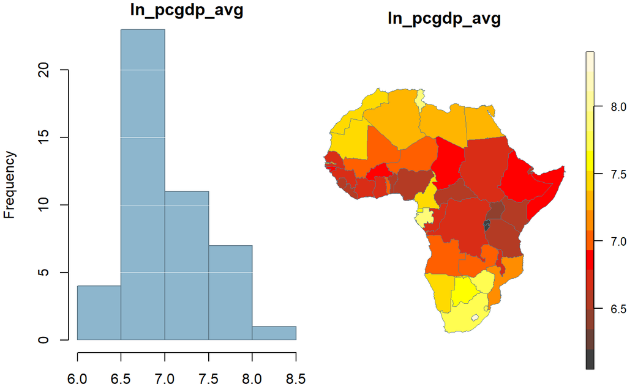

```r
computeLocalAvg <- function(dsp, variable_name, wlist)
{
   local_averages <- numeric(nrow(dsp)) # Initialize a vector to store the results
   for (i in 1:nrow(dsp))
   {
      neighbors_i <- wlist$neighbours[[i]] #nblist[[i]] # Neighbors of area i
      weights_i <- wlist$weights[[i]] #wlist[[i]]

      if (length(neighbors_i) > 0)
      { # Check if the area has neighbors (for islands or edge cases)
         neighbor_values <- dsp@data[neighbors_i, variable_name]  # values of the neighbors
         #print(neighbor_values)
         local_averages[i] <- sum(weights_i * neighbor_values)/sum(weights_i) # weighted average
      }
      else
      { # Handle cases with no neighbors (e.g., islands):
         local_averages[i] <- dsp@data[i, variable_name]
         warning(paste("Area", i, "has no neighbors.")) # or print a message
      }
   }

   return(local_averages)
}


showMapByQuintiles <- function(dsp, variable_name, mydata)
{
   dsp_sf = st_as_sf(dsp)  # Convert to sf object
   dsp_sf$mydata <- mydata

   brks=quantile(mydata, seq(0, 1, 0.2), na.rm=T);
   brks[1] = floor(brks[1]*10)/10;
   brks[length(brks)]=ceiling(brks[length(brks)]*10)/10
   spplot(as_Spatial(dsp_sf), 'mydata', main=paste('Quintile cuts: ', variable_name), lwd=0.5,
       at = brks,
       col = 'lightskyblue4',
       # col.regions = colorRampPalette(rev(brewer.pal(11, "Spectral")))(256),
       col.regions = matlab.like.hot(16),
       par.settings = list(axis.line = list(col = NA)))
}


# brks=quantile(slaveTrade$ln_pcgdp, seq(0, 1, 0.2), na.rm=T);
# brks[1] = floor(brks[1]*10)/10;
# brks[length(brks)]=ceiling(brks[length(brks)]*10)/10
# spplot(slaveTrade, c('ln_pcgdp'), main='ln_pcgdp', lwd=0.5,
#        at = brks,
#        #col.regions = colorRampPalette(rev(brewer.pal(11, "Spectral")))(256),
#        col.regions = matlab.like.hot(16),
#        par.settings = list(axis.line = list(col = NA)))

ln_pcgdp_avg = computeLocalAvg(slaveTrade, 'ln_pcgdp', slaveTrade.lw)

dsp_dummy=slaveTrade; dsp_dummy$ln_pcgdp_avg = ln_pcgdp_avg
showData(dsp_dummy,'ln_pcgdp_avg')
```

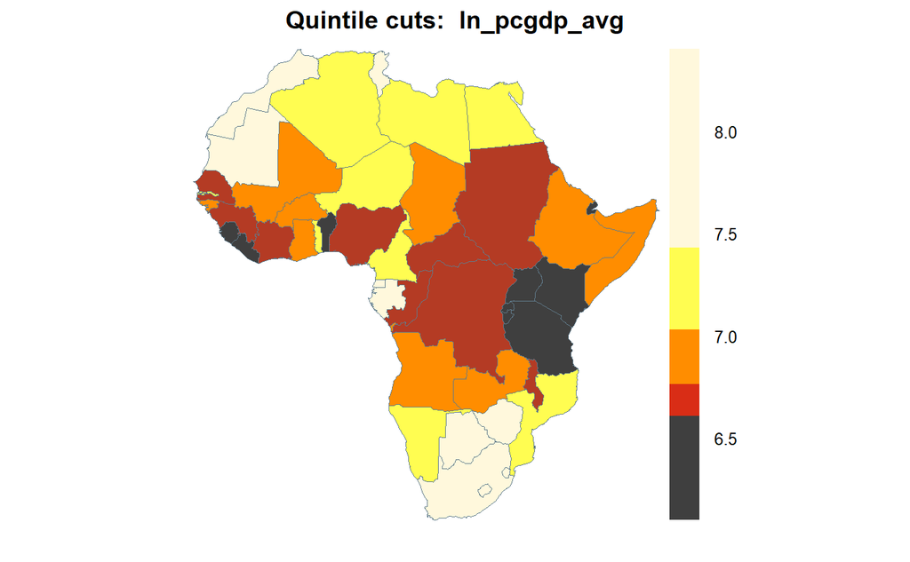

```r
showMapByQuintiles(slaveTrade, 'ln_pcgdp_avg', ln_pcgdp_avg)
```

```r
moran.test(slaveTrade$ln_pcgdp, slaveTrade.lw)
```

```
    Moran I test under randomisation

data:  slaveTrade$ln_pcgdp
weights: slaveTrade.lw

Moran I statistic standard deviate = 4.3832, p-value = 5.847e-06
alternative hypothesis: greater
sample estimates:
Moran I statistic       Expectation          Variance
       0.42321222       -0.02222222        0.01032717
```

```r
corD<-correlog(coordinates(slaveTrade), slaveTrade$ln_pcgdp, method="Moran")
corD = cbind(corD, corD[,1:2]); colnames(corD)[5:6] = c('my_Moran', 'my_pvalue')
for (k in 1:nrow(corD))
{
   if (k<=length(slaveTrade.nb.lag))
   {
      nb_lag = slaveTrade.nb.lag[[k]]
      lw_klag <- nb2listw(nb_lag, style = 'W')
      resk = moran.test(slaveTrade$ln_pcgdp, lw_klag)
      corD[k,5] = resk$estimate[1];
      corD[k,6] = resk$p.value;
   }
   else
   {
      corD[k,5] = NA
      corD[k,6] = NA
   }
}
(corD)
```

```
      dist.class         coef      p.value   n    my_Moran    my_pvalue
 [1,]     472379  0.581321114 1.430501e-05 102  0.42321222 5.846936e-06
 [2,]    1103686  0.214094436 8.420569e-03 214 -0.09532285 8.516463e-01
 [3,]    1734993 -0.145930298 8.950403e-01 218 -0.20962476 9.985113e-01
 [4,]    2366300 -0.244325064 9.950600e-01 264 -0.11027096 9.035166e-01
 [5,]    2997607 -0.122315364 8.783822e-01 262  0.13563682 2.773817e-02
 [6,]    3628914  0.155421053 1.812701e-02 256          NA           NA
 [7,]    4260221 -0.075661501 6.954287e-01 188          NA           NA
 [8,]    4891528 -0.285111943 9.964635e-01 208          NA           NA
 [9,]    5522835 -0.076877245 6.657695e-01 156          NA           NA
[10,]    6154142  0.130179157 9.734806e-02 126          NA           NA
[11,]    6785449  0.183756900 8.884203e-02  62          NA           NA
[12,]    7416756 -0.009985953 2.489103e-01  14          NA           NA
```

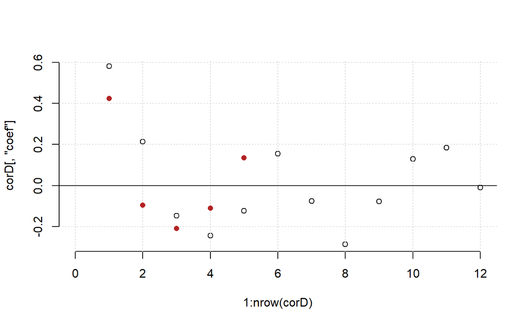

```r
plot(x=1:nrow(corD), y=corD[,'coef'], col='black', xlim=c(0,nrow(corD)), bty='n'); grid()
points(x=1:nrow(corD), y=corD[,'my_Moran'], col='firebrick', pch=16, add=T)
abline(a=0,b=0,lwd=1)

corD<-correlog(coordinates(slaveTrade), ln_pcgdp_avg, method="Moran")
par(mar=c(4, 3, 2, 0))
```

```r
barplot(corD[,'coef'], names.arg=1:length(corD[,'coef']), yaxt = "n",
        main=paste('correlog. ', 'ln_pcgdp_avg'), xlab='lag', ylim=c(-1,1),
        col='lightskyblue3', border='lightskyblue4')
axis(2,  # 2 indicates the left axis (y-axis)
     at = seq(-1,1,0.2),  # Positions of the ticks
     labels = seq(-1,1,0.2))
```

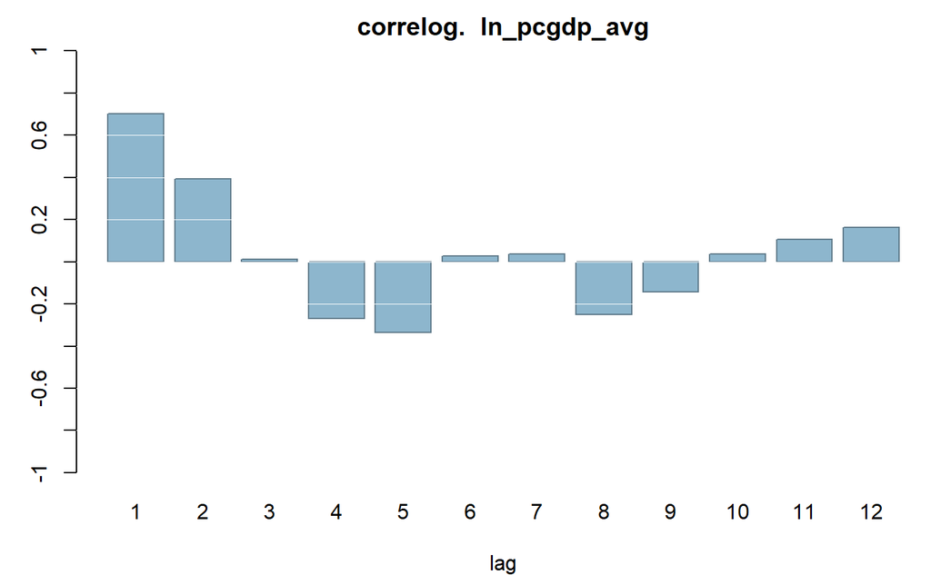

```r
#grid(lty='solid', lwd=0.5, col='white', nx=NA, ny=NULL)
abline(h = seq(-1,1,0.2), col = "white", lty = 'solid', lwd=0.5) # Add gridlines at y_ticks
par(mar=c(5, 4, 4, 2)+0.1)
```

```r
NA
NA
```

### Local Moran

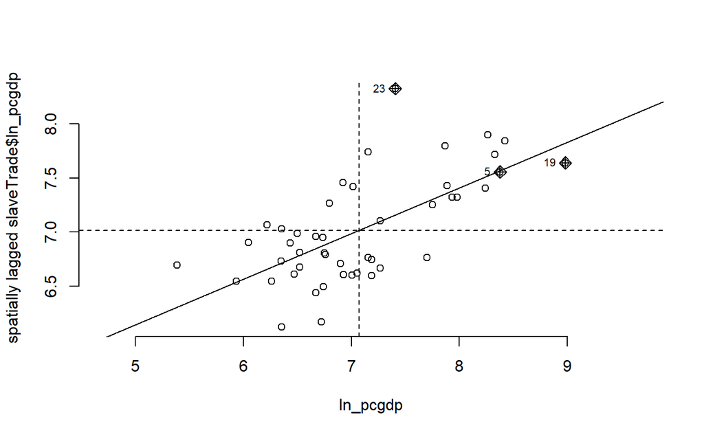

```r
set.seed(42)
moran.plot(slaveTrade$ln_pcgdp, slaveTrade.lw,
           xlab='ln_pcgdp', asp=1, bty='n')
```

```r
print(slaveTrade$isocode[c(5,19,23)])
```

```
[1] "BWA" "GNQ" "LSO"
```

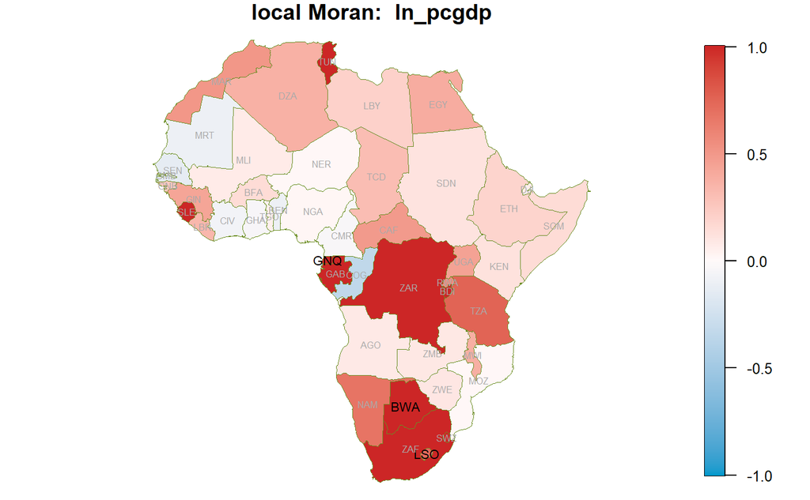

```r
lmii = localmoran(slaveTrade$ln_pcgdp, slaveTrade.lw)
# lmii = localmoran_perm(slaveTrade$ln_pcgdp, slaveTrade.lw, nsim=999, iseed=123456789)

showMoran(slaveTrade, lmii, 'ln_pcgdp', c(5,19,23))
```

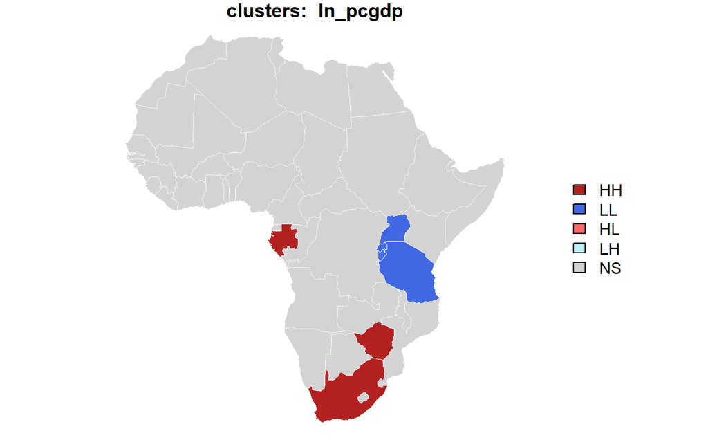

```r
showClusterMap(slaveTrade, lmii, 'ln_pcgdp', significance_level=0.05)
```

## Trattamento (ln_export_area)

### Media

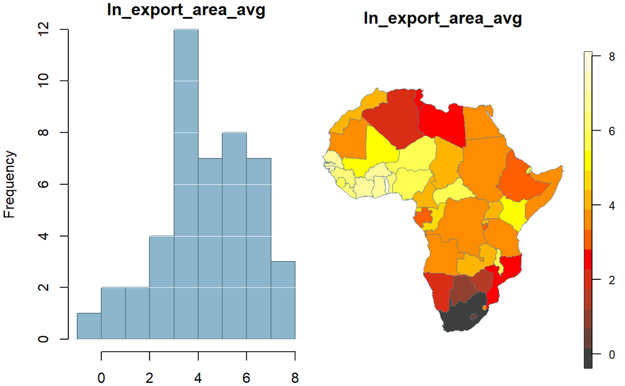

```r
ln_export_area_avg = computeLocalAvg(slaveTrade, 'ln_export_area', slaveTrade.lw)

dsp_dummy=slaveTrade; dsp_dummy$ln_export_area_avg = ln_export_area_avg
showData(dsp_dummy,'ln_export_area_avg')
```

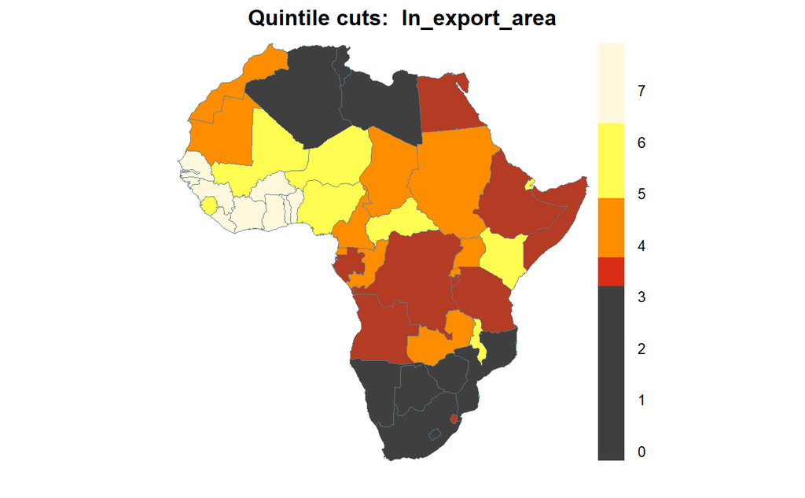

```r
showMapByQuintiles(slaveTrade, 'ln_export_area', ln_export_area_avg)
```

### Local Moran

```r
moran.test(slaveTrade$ln_export_area, slaveTrade.lw)
```

```
    Moran I test under randomisation

data:  slaveTrade$ln_export_area
weights: slaveTrade.lw

Moran I statistic standard deviate = 3.1916, p-value = 0.0007075
alternative hypothesis: greater
sample estimates:
Moran I statistic       Expectation          Variance
       0.30551706       -0.02222222        0.01054508
```

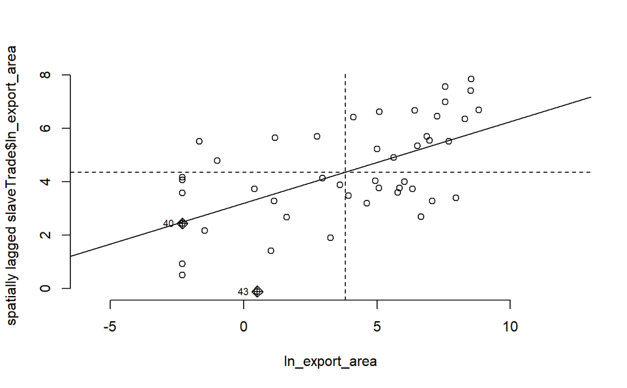

```r
mr = moran.plot(slaveTrade$ln_export_area, slaveTrade.lw,
           xlab='ln_export_area', asp=1, bty='n')
```

```r
print(slaveTrade$isocode[c(40,43)])
```

```
[1] "TUN" "ZAF"
```

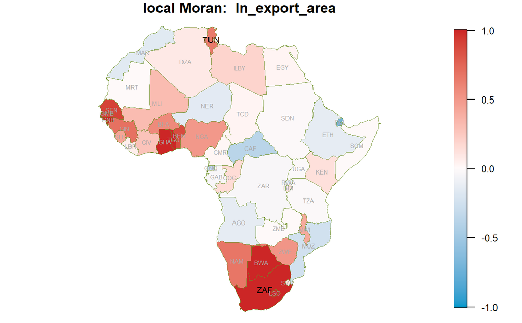

```r
lmii = localmoran(slaveTrade$ln_export_area, slaveTrade.lw)
# lmii = localmoran_perm(slaveTrade$ln_export_area, slaveTrade.lw, nsim=999, iseed=123456789)
showMoran(slaveTrade, lmii, 'ln_export_area',  c(40,43))
```

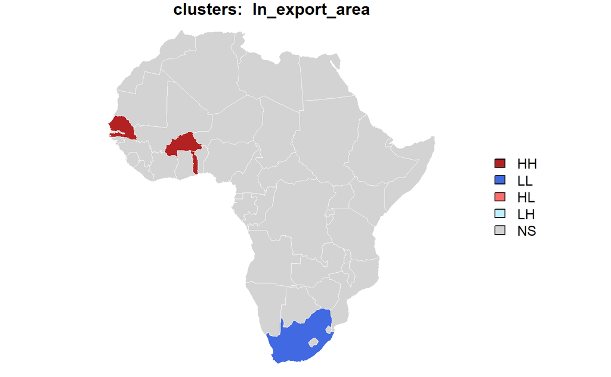

```r
showClusterMap(slaveTrade, lmii, 'ln_export_area')
```

# Modelli di Regressione

```r
fmla <- ln_pcgdp ~ ln_export_area + colony1 + colony2 +colony3 + colony4 + colony5 + colony6 + colony7 + rain_min + humid_max + low_temp + ln_coast_area + islam + legor_fr + region_n + ln_gold_pop + ln_oil_pop + ln_diamonds_pop
```

## Modello lineare

```r
modLM <- lm(fmla, data = slaveTrade)
summary(modLM)
```

```
Call:
lm(formula = fmla, data = slaveTrade)

Residuals:
     Min       1Q   Median       3Q      Max
-0.54419 -0.22749 -0.01176  0.17298  0.75527

Coefficients:
                 Estimate Std. Error t value Pr(>|t|)
(Intercept)      6.409676   0.880992   7.276 7.96e-08 ***
ln_export_area  -0.090781   0.025850  -3.512  0.00158 **
colony1          0.947924   0.449902   2.107  0.04455 *
colony2          1.043905   0.441921   2.362  0.02563 *
colony3          0.867653   0.454028   1.911  0.06667 .
colony4          0.257498   0.582354   0.442  0.66189
colony5          1.559744   0.705872   2.210  0.03579 *
colony6          1.570997   0.727731   2.159  0.03992 *
colony7          0.469763   0.648013   0.725  0.47473
rain_min         0.001658   0.007255   0.229  0.82096
humid_max        0.016627   0.008935   1.861  0.07367 .
low_temp        -0.053279   0.016356  -3.257  0.00303 **
ln_coast_area    0.099378   0.035313   2.814  0.00901 **
islam           -0.002329   0.002782  -0.837  0.40971
legor_fr         0.010320   0.421089   0.025  0.98063
region_n        -0.131477   0.379578  -0.346  0.73174
ln_gold_pop      0.012940   0.013661   0.947  0.35193
ln_oil_pop       0.077399   0.022307   3.470  0.00177 **
ln_diamonds_pop -0.021472   0.035204  -0.610  0.54701
---
Signif. codes:  0 ‘***’ 0.001 ‘**’ 0.01 ‘*’ 0.05 ‘.’ 0.1 ‘ ’ 1

Residual standard error: 0.404 on 27 degrees of freedom
Multiple R-squared:  0.8326,    Adjusted R-squared:  0.7209
F-statistic: 7.459 on 18 and 27 DF,  p-value: 2.204e-06
```

### Test di Moran sui residui

```r
moran.test(residuals(modLM), slaveTrade.lw)
```

```
    Moran I test under randomisation

data:  residuals(modLM)
weights: slaveTrade.lw

Moran I statistic standard deviate = -0.36075, p-value = 0.6409
alternative hypothesis: greater
sample estimates:
Moran I statistic       Expectation          Variance
      -0.05897598       -0.02222222        0.01037988
```

```r
lm.morantest(modLM, slaveTrade.lw)
```

```
    Global Moran I for regression residuals

data:
model: lm(formula = fmla, data = slaveTrade)
weights: slaveTrade.lw

Moran I statistic standard deviate = 0.55695, p-value = 0.2888
alternative hypothesis: greater
sample estimates:
Observed Moran I      Expectation         Variance
    -0.058975984     -0.108068846      0.007769563
```

### Test di Rao

Anche se dal test di Moran risulta assenza di struttura spaziale sui residui, e pertanto quanto osservato su `ln_pcgdp` è già spiegato dalle covariate impiegate, applichiamo anche il test dei moltiplicatori di Lagrange (o test di Rao) per valutare la necessità di un modello a struttura spaziale, tramite `lm.RStests()`.

La funzione `lm.RStests()` restituisce

- il test RSerr (LM-error, per SEM), che verifica l’autocorrelazione spaziale nel termine di errore;
- il test RSlag (LM-lag, per SLM), che verifica l’autocorrelazione spaziale nella variabile dipendente;
- le versioni robuste dei precedenti test;
- il test SARMA che verifica la dipendenza combinata tra lag spaziale ed errore.

```r
#Rao's score (a.k.a Lagrange multiplier) diagnostics
lmtest = lm.RStests(modLM,listw = slaveTrade.lw, test="all" )
summary(lmtest)
```

```
    Rao's score (a.k.a Lagrange multiplier) diagnostics for spatial dependence
data:
model: lm(formula = fmla, data = slaveTrade)
test weights: slaveTrade.lw

         statistic parameter p.value
RSerr    0.3052046         1  0.5806
RSlag    0.0099526         1  0.9205
adjRSerr 0.4906222         1  0.4836
adjRSlag 0.1953702         1  0.6585
SARMA    0.5005748         2  0.7786
```

Gli elvati p-value forniti da tutti i test sembrano indicare che non esista nessuna dipendenza statisticamente significativa da una struttura spaziale.

Decidiamo comunque di applicare anche gli Spatial Error Model (SEM), Spatial Lag Model (SLM) e lo Spatial Durbin Model (SDM) per ulteriore conferma.

## Spatial Error Model

```r
library(spatialreg)
modSEM <- errorsarlm(fmla, data = slaveTrade, listw = slaveTrade.lw)
summary(modSEM)
```

```
Call:errorsarlm(formula = fmla, data = slaveTrade, listw = slaveTrade.lw)

Residuals:
      Min        1Q    Median        3Q       Max
-0.492646 -0.216874 -0.047111  0.218542  0.611678

Type: error
Coefficients: (asymptotic standard errors)
                  Estimate Std. Error z value  Pr(>|z|)
(Intercept)      4.7163055  0.6755299  6.9816 2.918e-12
ln_export_area  -0.0599673  0.0176409 -3.3993 0.0006755
colony1          2.1542058  0.3550998  6.0665 1.307e-09
colony2          1.8236501  0.3169903  5.7530 8.767e-09
colony3          1.2430111  0.3353017  3.7071 0.0002096
colony4          1.1397081  0.3827486  2.9777 0.0029043
colony5          2.5782346  0.4802824  5.3682 7.954e-08
colony6          2.8080166  0.5338434  5.2600 1.441e-07
colony7          1.6344453  0.5735883  2.8495 0.0043787
rain_min         0.0082390  0.0047167  1.7468 0.0806799
humid_max        0.0230702  0.0067576  3.4140 0.0006402
low_temp        -0.0772995  0.0108697 -7.1115 1.148e-12
ln_coast_area    0.1478062  0.0235635  6.2727 3.549e-10
islam           -0.0022717  0.0017485 -1.2992 0.1938658
legor_fr         0.6507630  0.3589125  1.8132 0.0698084
region_n        -0.2911240  0.2332548 -1.2481 0.2119964
ln_gold_pop      0.0158570  0.0106232  1.4927 0.1355246
ln_oil_pop       0.0514046  0.0142822  3.5992 0.0003192
ln_diamonds_pop  0.0016549  0.0251344  0.0658 0.9475043

Lambda: -0.91746, LR test value: 2.344, p-value: 0.12577
Asymptotic standard error: 0.1741
    z-value: -5.2696, p-value: 1.3672e-07
Wald statistic: 27.769, p-value: 1.3672e-07

Log likelihood: -10.15064 for error model
ML residual variance (sigma squared): 0.075562, (sigma: 0.27489)
Number of observations: 46
Number of parameters estimated: 21
AIC: 62.301, (AIC for lm: 62.645)
```

```r
modSEM$coefficients["lambda"]
```

```
<NA>
  NA
```

### Test di Moran sui residui

```r
moran.test(residuals(modSEM), slaveTrade.lw)
```

```
    Moran I test under randomisation

data:  residuals(modSEM)
weights: slaveTrade.lw

Moran I statistic standard deviate = -0.27332, p-value = 0.6077
alternative hypothesis: greater
sample estimates:
Moran I statistic       Expectation          Variance
      -0.05021622       -0.02222222        0.01049021
```